# group work project 1 (1)

```python
import pandas as pd
import matplotlib.pyplot as plt
import seaborn as sns
from matplotlib import *
import quandl
from pylab import rcParams # sizing
rcParams['figure.figsize'] = 20, 20
import yfinance as yf
```

```python
#iShares Gold Trust (IAU) download required data for analysis purpose
gold_etf=yf.download("IAU",start="2019-10-01",end="2019-11-30")
```

```
[*********************100%***********************]  1 of 1 completed
```

```python
gold_etf # dataframe represntation of gold etf data from oct1 2019  to 29Nov 2019
```

| Date | Open | High | Low | Close | Adj Close | Volume |
| --- | --- | --- | --- | --- | --- | --- |
| 2019-09-30 | 14.19 | 14.23 | 14.00 | 14.10 | 14.10 | 17681900 |
| 2019-10-01 | 14.01 | 14.23 | 13.98 | 14.17 | 14.17 | 27078500 |
| 2019-10-02 | 14.29 | 14.40 | 14.25 | 14.34 | 14.34 | 25880200 |
| 2019-10-03 | 14.34 | 14.54 | 14.34 | 14.41 | 14.41 | 30910300 |
| 2019-10-04 | 14.36 | 14.44 | 14.33 | 14.41 | 14.41 | 26357900 |
| 2019-10-07 | 14.33 | 14.39 | 14.23 | 14.28 | 14.28 | 22807800 |
| 2019-10-08 | 14.42 | 14.44 | 14.32 | 14.41 | 14.41 | 41484700 |
| 2019-10-09 | 14.43 | 14.47 | 14.37 | 14.42 | 14.42 | 17320400 |
| 2019-10-10 | 14.37 | 14.37 | 14.26 | 14.29 | 14.29 | 18505700 |
| 2019-10-11 | 14.20 | 14.22 | 14.10 | 14.21 | 14.21 | 31670800 |
| 2019-10-14 | 14.26 | 14.29 | 14.24 | 14.26 | 14.26 | 6433300 |
| 2019-10-15 | 14.23 | 14.24 | 14.13 | 14.18 | 14.18 | 17750000 |
| 2019-10-16 | 14.23 | 14.26 | 14.17 | 14.25 | 14.25 | 12967200 |
| 2019-10-17 | 14.25 | 14.32 | 14.25 | 14.27 | 14.27 | 10201900 |
| 2019-10-18 | 14.26 | 14.28 | 14.24 | 14.25 | 14.25 | 7902900 |
| 2019-10-21 | 14.27 | 14.29 | 14.17 | 14.18 | 14.18 | 7589600 |
| 2019-10-22 | 14.22 | 14.24 | 14.18 | 14.23 | 14.23 | 7297800 |
| 2019-10-23 | 14.26 | 14.31 | 14.26 | 14.27 | 14.27 | 10742100 |
| 2019-10-24 | 14.31 | 14.38 | 14.30 | 14.37 | 14.37 | 12788800 |
| 2019-10-25 | 14.50 | 14.50 | 14.35 | 14.40 | 14.40 | 16223100 |
| 2019-10-28 | 14.34 | 14.34 | 14.25 | 14.27 | 14.27 | 13739900 |
| 2019-10-29 | 14.21 | 14.27 | 14.19 | 14.22 | 14.22 | 13785900 |
| 2019-10-30 | 14.26 | 14.32 | 14.16 | 14.32 | 14.32 | 19324300 |
| 2019-10-31 | 14.41 | 14.48 | 14.40 | 14.46 | 14.46 | 17305400 |
| 2019-11-01 | 14.44 | 14.50 | 14.41 | 14.46 | 14.46 | 17684400 |
| 2019-11-04 | 14.44 | 14.46 | 14.38 | 14.43 | 14.43 | 16009300 |
| 2019-11-05 | 14.28 | 14.30 | 14.14 | 14.19 | 14.19 | 20536100 |
| 2019-11-06 | 14.22 | 14.29 | 14.20 | 14.26 | 14.26 | 15263500 |
| 2019-11-07 | 14.21 | 14.23 | 13.97 | 14.03 | 14.03 | 25561100 |
| 2019-11-08 | 13.97 | 14.04 | 13.94 | 13.95 | 13.95 | 14966900 |
| 2019-11-11 | 13.96 | 13.99 | 13.84 | 13.90 | 13.90 | 15544100 |
| 2019-11-12 | 13.91 | 13.96 | 13.82 | 13.95 | 13.95 | 17718100 |
| 2019-11-13 | 13.99 | 14.03 | 13.96 | 14.00 | 14.00 | 17707700 |
| 2019-11-14 | 14.05 | 14.10 | 14.00 | 14.06 | 14.06 | 11884900 |
| 2019-11-15 | 14.01 | 14.05 | 14.00 | 14.03 | 14.03 | 9137300 |
| 2019-11-18 | 14.05 | 14.09 | 14.03 | 14.08 | 14.08 | 11366500 |
| 2019-11-19 | 14.01 | 14.10 | 14.01 | 14.08 | 14.08 | 8889000 |
| 2019-11-20 | 14.06 | 14.11 | 14.01 | 14.08 | 14.08 | 18867100 |
| 2019-11-21 | 14.05 | 14.06 | 13.98 | 14.00 | 14.00 | 13545500 |
| 2019-11-22 | 14.04 | 14.05 | 13.97 | 13.98 | 13.98 | 13684400 |
| 2019-11-25 | 13.94 | 13.96 | 13.90 | 13.91 | 13.91 | 11340900 |
| 2019-11-26 | 13.90 | 13.99 | 13.86 | 13.98 | 13.98 | 10558100 |
| 2019-11-27 | 13.91 | 13.93 | 13.88 | 13.91 | 13.91 | 9490300 |
| 2019-11-29 | 13.91 | 14.02 | 13.90 | 13.98 | 13.98 | 8800600 |

```python
# kotal mahindra it is indian private sector bank we are using Kotak Nifty Exchange Traded Scheme for analysis purpose
equity_etf=yf.download("KOTAKNIFTY.NS",start="2019-09-30",end="2019-11-30")
```

```
[*********************100%***********************]  1 of 1 completed
```

```python
equity_etf
```

| Date | Open | High | Low | Close | Adj Close | Volume |
| --- | --- | --- | --- | --- | --- | --- |
| 2019-09-30 | 119.559998 | 119.699997 | 118.230003 | 119.459999 | 119.459999 | 487481 |
| 2019-10-01 | 119.510002 | 120.000000 | 117.000000 | 117.489998 | 117.489998 | 220359 |
| 2019-10-03 | 117.010002 | 117.790001 | 116.500000 | 117.080002 | 117.080002 | 34831 |
| 2019-10-04 | 117.400002 | 117.900002 | 115.949997 | 116.029999 | 116.029999 | 96496 |
| 2019-10-07 | 116.150002 | 116.699997 | 115.360001 | 115.820000 | 115.820000 | 196701 |
| 2019-10-09 | 118.099998 | 128.600006 | 115.250000 | 116.970001 | 116.970001 | 55017 |
| 2019-10-10 | 116.820000 | 117.080002 | 116.059998 | 116.449997 | 116.449997 | 18463 |
| 2019-10-11 | 116.690002 | 117.470001 | 115.809998 | 116.699997 | 116.699997 | 27325 |
| 2019-10-14 | 117.000000 | 117.900002 | 116.800003 | 117.309998 | 117.309998 | 58123 |
| 2019-10-15 | 117.599998 | 118.400002 | 117.300003 | 118.000000 | 118.000000 | 65235 |
| 2019-10-16 | 115.599998 | 118.699997 | 105.000000 | 118.180000 | 118.180000 | 84462 |
| 2019-10-17 | 118.019997 | 119.639999 | 118.019997 | 119.489998 | 119.489998 | 29533 |
| 2019-10-18 | 118.949997 | 121.000000 | 118.949997 | 120.360001 | 120.360001 | 102418 |
| 2019-10-22 | 120.610001 | 121.000000 | 119.750000 | 119.980003 | 119.980003 | 69537 |
| 2019-10-23 | 120.000000 | 120.500000 | 119.500000 | 119.599998 | 119.599998 | 31506 |
| 2019-10-24 | 120.059998 | 120.779999 | 119.500000 | 119.910004 | 119.910004 | 49399 |
| 2019-10-25 | 119.989998 | 120.599998 | 119.500000 | 120.339996 | 120.339996 | 142949 |
| 2019-10-29 | 120.160004 | 122.000000 | 120.120003 | 121.739998 | 121.739998 | 63187 |
| 2019-10-30 | 121.699997 | 122.680000 | 121.699997 | 122.120003 | 122.120003 | 56824 |
| 2019-10-31 | 122.389999 | 123.199997 | 122.199997 | 122.519997 | 122.519997 | 44133 |
| 2019-11-01 | 122.500000 | 123.680000 | 122.260002 | 122.839996 | 122.839996 | 1083750 |
| 2019-11-04 | 123.169998 | 123.889999 | 122.489998 | 123.279999 | 123.279999 | 101711 |
| 2019-11-05 | 123.099998 | 123.550003 | 122.599998 | 123.220001 | 123.220001 | 25714 |
| 2019-11-06 | 123.000000 | 124.000000 | 122.559998 | 123.589996 | 123.589996 | 41912 |
| 2019-11-07 | 123.599998 | 124.300003 | 123.500000 | 124.000000 | 124.000000 | 603936 |
| 2019-11-08 | 123.800003 | 124.650002 | 123.000000 | 123.269997 | 123.269997 | 125395 |
| 2019-11-11 | 123.110001 | 123.720001 | 122.470001 | 123.190002 | 123.190002 | 41667 |
| 2019-11-13 | 123.389999 | 123.550003 | 122.169998 | 122.339996 | 122.339996 | 24139 |
| 2019-11-14 | 122.680000 | 123.000000 | 121.900002 | 122.480003 | 122.480003 | 1377969 |
| 2019-11-15 | 124.900002 | 125.000000 | 122.519997 | 123.089996 | 123.089996 | 896449 |
| 2019-11-18 | 123.309998 | 123.320000 | 122.739998 | 122.769997 | 122.769997 | 94057 |
| 2019-11-19 | 123.300003 | 123.500000 | 122.550003 | 123.360001 | 123.360001 | 56442 |
| 2019-11-20 | 120.900002 | 125.800003 | 109.800003 | 123.779999 | 123.779999 | 90583 |
| 2019-11-21 | 124.000000 | 124.400002 | 122.150002 | 123.900002 | 123.900002 | 43621 |
| 2019-11-22 | 123.900002 | 123.900002 | 122.900002 | 122.989998 | 122.989998 | 16117 |
| 2019-11-25 | 123.230003 | 124.620003 | 122.919998 | 124.570000 | 124.570000 | 170112 |
| 2019-11-26 | 124.650002 | 124.949997 | 124.040001 | 124.739998 | 124.739998 | 322450 |
| 2019-11-27 | 124.620003 | 124.970001 | 124.599998 | 124.860001 | 124.860001 | 28778 |
| 2019-11-28 | 124.739998 | 126.449997 | 124.739998 | 126.300003 | 126.300003 | 948845 |
| 2019-11-29 | 126.220001 | 126.220001 | 124.800003 | 125.339996 | 125.339996 | 19046 |

```python
# using quandle API to fetch US treasury yeild data for 6 benchmark securities(Octomber 2019 to November 2019)
QUANDL_KEY = '7fxpQS8ehy19Mg-aJAix' # replace {key} with your own API key
quandl.ApiConfig.api_key = QUANDL_KEY
us_treasury=quandl.get(dataset='USTREASURY/YIELD',
start_date='2019-10-01',
end_date='2019-11-30')
us_treasury
```

| Date | 1 MO | 2 MO | 3 MO | 6 MO | 1 YR | 2 YR | 3 YR | 5 YR | 7 YR | 10 YR | 20 YR | 30 YR |
| --- | --- | --- | --- | --- | --- | --- | --- | --- | --- | --- | --- | --- |
| 2019-10-01 | 1.79 | 1.77 | 1.82 | 1.81 | 1.73 | 1.56 | 1.51 | 1.51 | 1.59 | 1.65 | 1.93 | 2.11 |
| 2019-10-02 | 1.75 | 1.75 | 1.79 | 1.75 | 1.67 | 1.48 | 1.43 | 1.43 | 1.53 | 1.60 | 1.90 | 2.09 |
| 2019-10-03 | 1.78 | 1.75 | 1.70 | 1.66 | 1.58 | 1.39 | 1.34 | 1.34 | 1.45 | 1.54 | 1.85 | 2.04 |
| 2019-10-04 | 1.73 | 1.74 | 1.71 | 1.65 | 1.58 | 1.40 | 1.35 | 1.34 | 1.43 | 1.52 | 1.81 | 2.01 |
| 2019-10-07 | 1.76 | 1.76 | 1.75 | 1.73 | 1.64 | 1.46 | 1.41 | 1.38 | 1.47 | 1.56 | 1.85 | 2.05 |
| 2019-10-08 | 1.69 | 1.72 | 1.72 | 1.69 | 1.62 | 1.42 | 1.38 | 1.36 | 1.45 | 1.54 | 1.84 | 2.04 |
| 2019-10-09 | 1.69 | 1.70 | 1.69 | 1.69 | 1.59 | 1.47 | 1.43 | 1.40 | 1.50 | 1.59 | 1.88 | 2.08 |
| 2019-10-10 | 1.74 | 1.71 | 1.68 | 1.68 | 1.63 | 1.53 | 1.49 | 1.48 | 1.57 | 1.67 | 1.96 | 2.16 |
| 2019-10-11 | 1.76 | 1.74 | 1.68 | 1.68 | 1.67 | 1.63 | 1.60 | 1.59 | 1.68 | 1.76 | 2.04 | 2.22 |
| 2019-10-15 | 1.74 | 1.72 | 1.67 | 1.67 | 1.65 | 1.61 | 1.60 | 1.59 | 1.68 | 1.77 | 2.06 | 2.23 |
| 2019-10-16 | 1.71 | 1.68 | 1.66 | 1.64 | 1.59 | 1.58 | 1.57 | 1.57 | 1.65 | 1.75 | 2.05 | 2.23 |
| 2019-10-17 | 1.74 | 1.70 | 1.66 | 1.63 | 1.59 | 1.60 | 1.57 | 1.57 | 1.66 | 1.76 | 2.05 | 2.24 |
| 2019-10-18 | 1.75 | 1.69 | 1.66 | 1.63 | 1.58 | 1.58 | 1.56 | 1.56 | 1.66 | 1.76 | 2.06 | 2.25 |
| 2019-10-21 | 1.76 | 1.70 | 1.67 | 1.65 | 1.59 | 1.62 | 1.59 | 1.61 | 1.70 | 1.80 | 2.10 | 2.28 |
| 2019-10-22 | 1.75 | 1.69 | 1.65 | 1.64 | 1.59 | 1.60 | 1.59 | 1.60 | 1.68 | 1.78 | 2.07 | 2.26 |
| 2019-10-23 | 1.74 | 1.69 | 1.65 | 1.64 | 1.58 | 1.58 | 1.58 | 1.58 | 1.67 | 1.77 | 2.06 | 2.25 |
| 2019-10-24 | 1.75 | 1.73 | 1.67 | 1.65 | 1.59 | 1.58 | 1.58 | 1.58 | 1.67 | 1.77 | 2.08 | 2.26 |
| 2019-10-25 | 1.73 | 1.72 | 1.66 | 1.66 | 1.60 | 1.63 | 1.62 | 1.62 | 1.71 | 1.80 | 2.10 | 2.29 |
| 2019-10-28 | 1.74 | 1.71 | 1.65 | 1.65 | 1.60 | 1.64 | 1.65 | 1.66 | 1.75 | 1.85 | 2.16 | 2.34 |
| 2019-10-29 | 1.66 | 1.67 | 1.63 | 1.64 | 1.59 | 1.64 | 1.65 | 1.66 | 1.74 | 1.84 | 2.15 | 2.33 |
| 2019-10-30 | 1.61 | 1.60 | 1.62 | 1.62 | 1.59 | 1.61 | 1.60 | 1.61 | 1.69 | 1.78 | 2.08 | 2.26 |
| 2019-10-31 | 1.59 | 1.59 | 1.54 | 1.57 | 1.53 | 1.52 | 1.52 | 1.51 | 1.60 | 1.69 | 2.00 | 2.17 |
| 2019-11-01 | 1.58 | 1.58 | 1.52 | 1.55 | 1.53 | 1.56 | 1.55 | 1.55 | 1.63 | 1.73 | 2.03 | 2.21 |
| 2019-11-04 | 1.58 | 1.57 | 1.53 | 1.57 | 1.56 | 1.60 | 1.59 | 1.60 | 1.69 | 1.79 | 2.10 | 2.27 |
| 2019-11-05 | 1.56 | 1.57 | 1.56 | 1.58 | 1.62 | 1.63 | 1.63 | 1.66 | 1.77 | 1.86 | 2.17 | 2.34 |
| 2019-11-06 | 1.55 | 1.56 | 1.56 | 1.57 | 1.58 | 1.61 | 1.60 | 1.63 | 1.73 | 1.81 | 2.13 | 2.30 |
| 2019-11-07 | 1.57 | 1.57 | 1.56 | 1.58 | 1.58 | 1.68 | 1.70 | 1.74 | 1.84 | 1.92 | 2.24 | 2.40 |
| 2019-11-08 | 1.56 | 1.56 | 1.55 | 1.58 | 1.58 | 1.68 | 1.70 | 1.74 | 1.86 | 1.94 | 2.27 | 2.43 |
| 2019-11-12 | 1.56 | 1.56 | 1.59 | 1.59 | 1.58 | 1.66 | 1.69 | 1.73 | 1.84 | 1.92 | 2.24 | 2.39 |
| 2019-11-13 | 1.56 | 1.57 | 1.57 | 1.59 | 1.57 | 1.63 | 1.65 | 1.69 | 1.79 | 1.88 | 2.20 | 2.36 |
| 2019-11-14 | 1.59 | 1.57 | 1.57 | 1.58 | 1.55 | 1.58 | 1.59 | 1.63 | 1.73 | 1.82 | 2.15 | 2.31 |
| 2019-11-15 | 1.59 | 1.56 | 1.57 | 1.59 | 1.54 | 1.61 | 1.61 | 1.65 | 1.75 | 1.84 | 2.16 | 2.31 |
| 2019-11-18 | 1.59 | 1.57 | 1.57 | 1.58 | 1.54 | 1.60 | 1.59 | 1.63 | 1.73 | 1.81 | 2.14 | 2.30 |
| 2019-11-19 | 1.58 | 1.57 | 1.57 | 1.58 | 1.54 | 1.60 | 1.59 | 1.63 | 1.71 | 1.79 | 2.11 | 2.26 |
| 2019-11-20 | 1.57 | 1.56 | 1.57 | 1.58 | 1.54 | 1.56 | 1.55 | 1.58 | 1.66 | 1.73 | 2.05 | 2.20 |
| 2019-11-21 | 1.57 | 1.57 | 1.58 | 1.59 | 1.55 | 1.60 | 1.59 | 1.62 | 1.71 | 1.77 | 2.09 | 2.24 |
| 2019-11-22 | 1.58 | 1.59 | 1.58 | 1.59 | 1.56 | 1.61 | 1.60 | 1.62 | 1.71 | 1.77 | 2.08 | 2.22 |
| 2019-11-25 | 1.60 | 1.60 | 1.61 | 1.61 | 1.58 | 1.61 | 1.60 | 1.62 | 1.71 | 1.76 | 2.07 | 2.21 |
| 2019-11-26 | 1.63 | 1.61 | 1.60 | 1.62 | 1.59 | 1.58 | 1.58 | 1.58 | 1.68 | 1.74 | 2.04 | 2.18 |
| 2019-11-27 | 1.65 | 1.60 | 1.62 | 1.63 | 1.60 | 1.63 | 1.61 | 1.63 | 1.71 | 1.77 | 2.06 | 2.19 |
| 2019-11-29 | 1.62 | 1.60 | 1.59 | 1.63 | 1.60 | 1.61 | 1.61 | 1.62 | 1.73 | 1.78 | 2.07 | 2.21 |

```python
us_treasury.drop(columns=['1 MO','2 MO','3 MO','6 MO','1 YR','20 YR'],inplace=True)
```

```python
us_treasury.shape
```

```
(41, 6)
```

```python
us_treasury
```

| Date | 2 YR | 3 YR | 5 YR | 7 YR | 10 YR | 30 YR |
| --- | --- | --- | --- | --- | --- | --- |
| 2019-10-01 | 1.56 | 1.51 | 1.51 | 1.59 | 1.65 | 2.11 |
| 2019-10-02 | 1.48 | 1.43 | 1.43 | 1.53 | 1.60 | 2.09 |
| 2019-10-03 | 1.39 | 1.34 | 1.34 | 1.45 | 1.54 | 2.04 |
| 2019-10-04 | 1.40 | 1.35 | 1.34 | 1.43 | 1.52 | 2.01 |
| 2019-10-07 | 1.46 | 1.41 | 1.38 | 1.47 | 1.56 | 2.05 |
| 2019-10-08 | 1.42 | 1.38 | 1.36 | 1.45 | 1.54 | 2.04 |
| 2019-10-09 | 1.47 | 1.43 | 1.40 | 1.50 | 1.59 | 2.08 |
| 2019-10-10 | 1.53 | 1.49 | 1.48 | 1.57 | 1.67 | 2.16 |
| 2019-10-11 | 1.63 | 1.60 | 1.59 | 1.68 | 1.76 | 2.22 |
| 2019-10-15 | 1.61 | 1.60 | 1.59 | 1.68 | 1.77 | 2.23 |
| 2019-10-16 | 1.58 | 1.57 | 1.57 | 1.65 | 1.75 | 2.23 |
| 2019-10-17 | 1.60 | 1.57 | 1.57 | 1.66 | 1.76 | 2.24 |
| 2019-10-18 | 1.58 | 1.56 | 1.56 | 1.66 | 1.76 | 2.25 |
| 2019-10-21 | 1.62 | 1.59 | 1.61 | 1.70 | 1.80 | 2.28 |
| 2019-10-22 | 1.60 | 1.59 | 1.60 | 1.68 | 1.78 | 2.26 |
| 2019-10-23 | 1.58 | 1.58 | 1.58 | 1.67 | 1.77 | 2.25 |
| 2019-10-24 | 1.58 | 1.58 | 1.58 | 1.67 | 1.77 | 2.26 |
| 2019-10-25 | 1.63 | 1.62 | 1.62 | 1.71 | 1.80 | 2.29 |
| 2019-10-28 | 1.64 | 1.65 | 1.66 | 1.75 | 1.85 | 2.34 |
| 2019-10-29 | 1.64 | 1.65 | 1.66 | 1.74 | 1.84 | 2.33 |
| 2019-10-30 | 1.61 | 1.60 | 1.61 | 1.69 | 1.78 | 2.26 |
| 2019-10-31 | 1.52 | 1.52 | 1.51 | 1.60 | 1.69 | 2.17 |
| 2019-11-01 | 1.56 | 1.55 | 1.55 | 1.63 | 1.73 | 2.21 |
| 2019-11-04 | 1.60 | 1.59 | 1.60 | 1.69 | 1.79 | 2.27 |
| 2019-11-05 | 1.63 | 1.63 | 1.66 | 1.77 | 1.86 | 2.34 |
| 2019-11-06 | 1.61 | 1.60 | 1.63 | 1.73 | 1.81 | 2.30 |
| 2019-11-07 | 1.68 | 1.70 | 1.74 | 1.84 | 1.92 | 2.40 |
| 2019-11-08 | 1.68 | 1.70 | 1.74 | 1.86 | 1.94 | 2.43 |
| 2019-11-12 | 1.66 | 1.69 | 1.73 | 1.84 | 1.92 | 2.39 |
| 2019-11-13 | 1.63 | 1.65 | 1.69 | 1.79 | 1.88 | 2.36 |
| 2019-11-14 | 1.58 | 1.59 | 1.63 | 1.73 | 1.82 | 2.31 |
| 2019-11-15 | 1.61 | 1.61 | 1.65 | 1.75 | 1.84 | 2.31 |
| 2019-11-18 | 1.60 | 1.59 | 1.63 | 1.73 | 1.81 | 2.30 |
| 2019-11-19 | 1.60 | 1.59 | 1.63 | 1.71 | 1.79 | 2.26 |
| 2019-11-20 | 1.56 | 1.55 | 1.58 | 1.66 | 1.73 | 2.20 |
| 2019-11-21 | 1.60 | 1.59 | 1.62 | 1.71 | 1.77 | 2.24 |
| 2019-11-22 | 1.61 | 1.60 | 1.62 | 1.71 | 1.77 | 2.22 |
| 2019-11-25 | 1.61 | 1.60 | 1.62 | 1.71 | 1.76 | 2.21 |
| 2019-11-26 | 1.58 | 1.58 | 1.58 | 1.68 | 1.74 | 2.18 |
| 2019-11-27 | 1.63 | 1.61 | 1.63 | 1.71 | 1.77 | 2.19 |
| 2019-11-29 | 1.61 | 1.61 | 1.62 | 1.73 | 1.78 | 2.21 |

```python
us_treasury
```

| Date | 2 YR | 3 YR | 5 YR | 7 YR | 10 YR | 30 YR |
| --- | --- | --- | --- | --- | --- | --- |
| 2019-10-01 | 1.56 | 1.51 | 1.51 | 1.59 | 1.65 | 2.11 |
| 2019-10-02 | 1.48 | 1.43 | 1.43 | 1.53 | 1.60 | 2.09 |
| 2019-10-03 | 1.39 | 1.34 | 1.34 | 1.45 | 1.54 | 2.04 |
| 2019-10-04 | 1.40 | 1.35 | 1.34 | 1.43 | 1.52 | 2.01 |
| 2019-10-07 | 1.46 | 1.41 | 1.38 | 1.47 | 1.56 | 2.05 |
| 2019-10-08 | 1.42 | 1.38 | 1.36 | 1.45 | 1.54 | 2.04 |
| 2019-10-09 | 1.47 | 1.43 | 1.40 | 1.50 | 1.59 | 2.08 |
| 2019-10-10 | 1.53 | 1.49 | 1.48 | 1.57 | 1.67 | 2.16 |
| 2019-10-11 | 1.63 | 1.60 | 1.59 | 1.68 | 1.76 | 2.22 |
| 2019-10-15 | 1.61 | 1.60 | 1.59 | 1.68 | 1.77 | 2.23 |
| 2019-10-16 | 1.58 | 1.57 | 1.57 | 1.65 | 1.75 | 2.23 |
| 2019-10-17 | 1.60 | 1.57 | 1.57 | 1.66 | 1.76 | 2.24 |
| 2019-10-18 | 1.58 | 1.56 | 1.56 | 1.66 | 1.76 | 2.25 |
| 2019-10-21 | 1.62 | 1.59 | 1.61 | 1.70 | 1.80 | 2.28 |
| 2019-10-22 | 1.60 | 1.59 | 1.60 | 1.68 | 1.78 | 2.26 |
| 2019-10-23 | 1.58 | 1.58 | 1.58 | 1.67 | 1.77 | 2.25 |
| 2019-10-24 | 1.58 | 1.58 | 1.58 | 1.67 | 1.77 | 2.26 |
| 2019-10-25 | 1.63 | 1.62 | 1.62 | 1.71 | 1.80 | 2.29 |
| 2019-10-28 | 1.64 | 1.65 | 1.66 | 1.75 | 1.85 | 2.34 |
| 2019-10-29 | 1.64 | 1.65 | 1.66 | 1.74 | 1.84 | 2.33 |
| 2019-10-30 | 1.61 | 1.60 | 1.61 | 1.69 | 1.78 | 2.26 |
| 2019-10-31 | 1.52 | 1.52 | 1.51 | 1.60 | 1.69 | 2.17 |
| 2019-11-01 | 1.56 | 1.55 | 1.55 | 1.63 | 1.73 | 2.21 |
| 2019-11-04 | 1.60 | 1.59 | 1.60 | 1.69 | 1.79 | 2.27 |
| 2019-11-05 | 1.63 | 1.63 | 1.66 | 1.77 | 1.86 | 2.34 |
| 2019-11-06 | 1.61 | 1.60 | 1.63 | 1.73 | 1.81 | 2.30 |
| 2019-11-07 | 1.68 | 1.70 | 1.74 | 1.84 | 1.92 | 2.40 |
| 2019-11-08 | 1.68 | 1.70 | 1.74 | 1.86 | 1.94 | 2.43 |
| 2019-11-12 | 1.66 | 1.69 | 1.73 | 1.84 | 1.92 | 2.39 |
| 2019-11-13 | 1.63 | 1.65 | 1.69 | 1.79 | 1.88 | 2.36 |
| 2019-11-14 | 1.58 | 1.59 | 1.63 | 1.73 | 1.82 | 2.31 |
| 2019-11-15 | 1.61 | 1.61 | 1.65 | 1.75 | 1.84 | 2.31 |
| 2019-11-18 | 1.60 | 1.59 | 1.63 | 1.73 | 1.81 | 2.30 |
| 2019-11-19 | 1.60 | 1.59 | 1.63 | 1.71 | 1.79 | 2.26 |
| 2019-11-20 | 1.56 | 1.55 | 1.58 | 1.66 | 1.73 | 2.20 |
| 2019-11-21 | 1.60 | 1.59 | 1.62 | 1.71 | 1.77 | 2.24 |
| 2019-11-22 | 1.61 | 1.60 | 1.62 | 1.71 | 1.77 | 2.22 |
| 2019-11-25 | 1.61 | 1.60 | 1.62 | 1.71 | 1.76 | 2.21 |
| 2019-11-26 | 1.58 | 1.58 | 1.58 | 1.68 | 1.74 | 2.18 |
| 2019-11-27 | 1.63 | 1.61 | 1.63 | 1.71 | 1.77 | 2.19 |
| 2019-11-29 | 1.61 | 1.61 | 1.62 | 1.73 | 1.78 | 2.21 |

# DATA PROCESSING

Question and Answers

# Q: 'Compute the daily returns of your Gold ETF and your Equity ETF

```python
# daily returns for gold_etf represted in new column in dataframe  ie Daily Returns
gold_etf=gold_etf.assign(
Daily_Returns=gold_etf.Close.pct_change() * 100
)
gold_etf
```

| Date | Open | High | Low | Close | Adj Close | Volume | Daily_Returns |
| --- | --- | --- | --- | --- | --- | --- | --- |
| 2019-09-30 | 14.19 | 14.23 | 14.00 | 14.10 | 14.10 | 17681900 | NaN |
| 2019-10-01 | 14.01 | 14.23 | 13.98 | 14.17 | 14.17 | 27078500 | 0.496452 |
| 2019-10-02 | 14.29 | 14.40 | 14.25 | 14.34 | 14.34 | 25880200 | 1.199718 |
| 2019-10-03 | 14.34 | 14.54 | 14.34 | 14.41 | 14.41 | 30910300 | 0.488143 |
| 2019-10-04 | 14.36 | 14.44 | 14.33 | 14.41 | 14.41 | 26357900 | 0.000000 |
| 2019-10-07 | 14.33 | 14.39 | 14.23 | 14.28 | 14.28 | 22807800 | -0.902152 |
| 2019-10-08 | 14.42 | 14.44 | 14.32 | 14.41 | 14.41 | 41484700 | 0.910365 |
| 2019-10-09 | 14.43 | 14.47 | 14.37 | 14.42 | 14.42 | 17320400 | 0.069398 |
| 2019-10-10 | 14.37 | 14.37 | 14.26 | 14.29 | 14.29 | 18505700 | -0.901526 |
| 2019-10-11 | 14.20 | 14.22 | 14.10 | 14.21 | 14.21 | 31670800 | -0.559832 |
| 2019-10-14 | 14.26 | 14.29 | 14.24 | 14.26 | 14.26 | 6433300 | 0.351866 |
| 2019-10-15 | 14.23 | 14.24 | 14.13 | 14.18 | 14.18 | 17750000 | -0.561009 |
| 2019-10-16 | 14.23 | 14.26 | 14.17 | 14.25 | 14.25 | 12967200 | 0.493651 |
| 2019-10-17 | 14.25 | 14.32 | 14.25 | 14.27 | 14.27 | 10201900 | 0.140354 |
| 2019-10-18 | 14.26 | 14.28 | 14.24 | 14.25 | 14.25 | 7902900 | -0.140157 |
| 2019-10-21 | 14.27 | 14.29 | 14.17 | 14.18 | 14.18 | 7589600 | -0.491226 |
| 2019-10-22 | 14.22 | 14.24 | 14.18 | 14.23 | 14.23 | 7297800 | 0.352604 |
| 2019-10-23 | 14.26 | 14.31 | 14.26 | 14.27 | 14.27 | 10742100 | 0.281103 |
| 2019-10-24 | 14.31 | 14.38 | 14.30 | 14.37 | 14.37 | 12788800 | 0.700767 |
| 2019-10-25 | 14.50 | 14.50 | 14.35 | 14.40 | 14.40 | 16223100 | 0.208766 |
| 2019-10-28 | 14.34 | 14.34 | 14.25 | 14.27 | 14.27 | 13739900 | -0.902772 |
| 2019-10-29 | 14.21 | 14.27 | 14.19 | 14.22 | 14.22 | 13785900 | -0.350387 |
| 2019-10-30 | 14.26 | 14.32 | 14.16 | 14.32 | 14.32 | 19324300 | 0.703231 |
| 2019-10-31 | 14.41 | 14.48 | 14.40 | 14.46 | 14.46 | 17305400 | 0.977656 |
| 2019-11-01 | 14.44 | 14.50 | 14.41 | 14.46 | 14.46 | 17684400 | 0.000000 |
| 2019-11-04 | 14.44 | 14.46 | 14.38 | 14.43 | 14.43 | 16009300 | -0.207467 |
| 2019-11-05 | 14.28 | 14.30 | 14.14 | 14.19 | 14.19 | 20536100 | -1.663207 |
| 2019-11-06 | 14.22 | 14.29 | 14.20 | 14.26 | 14.26 | 15263500 | 0.493310 |
| 2019-11-07 | 14.21 | 14.23 | 13.97 | 14.03 | 14.03 | 25561100 | -1.612907 |
| 2019-11-08 | 13.97 | 14.04 | 13.94 | 13.95 | 13.95 | 14966900 | -0.570206 |
| 2019-11-11 | 13.96 | 13.99 | 13.84 | 13.90 | 13.90 | 15544100 | -0.358424 |
| 2019-11-12 | 13.91 | 13.96 | 13.82 | 13.95 | 13.95 | 17718100 | 0.359714 |
| 2019-11-13 | 13.99 | 14.03 | 13.96 | 14.00 | 14.00 | 17707700 | 0.358424 |
| 2019-11-14 | 14.05 | 14.10 | 14.00 | 14.06 | 14.06 | 11884900 | 0.428574 |
| 2019-11-15 | 14.01 | 14.05 | 14.00 | 14.03 | 14.03 | 9137300 | -0.213376 |
| 2019-11-18 | 14.05 | 14.09 | 14.03 | 14.08 | 14.08 | 11366500 | 0.356381 |
| 2019-11-19 | 14.01 | 14.10 | 14.01 | 14.08 | 14.08 | 8889000 | 0.000000 |
| 2019-11-20 | 14.06 | 14.11 | 14.01 | 14.08 | 14.08 | 18867100 | 0.000000 |
| 2019-11-21 | 14.05 | 14.06 | 13.98 | 14.00 | 14.00 | 13545500 | -0.568181 |
| 2019-11-22 | 14.04 | 14.05 | 13.97 | 13.98 | 13.98 | 13684400 | -0.142860 |
| 2019-11-25 | 13.94 | 13.96 | 13.90 | 13.91 | 13.91 | 11340900 | -0.500713 |
| 2019-11-26 | 13.90 | 13.99 | 13.86 | 13.98 | 13.98 | 10558100 | 0.503233 |
| 2019-11-27 | 13.91 | 13.93 | 13.88 | 13.91 | 13.91 | 9490300 | -0.500713 |
| 2019-11-29 | 13.91 | 14.02 | 13.90 | 13.98 | 13.98 | 8800600 | 0.503233 |

```python
gold_etf=gold_etf[gold_etf.index>="2019-10-01"] # dropping 30 th september  data
gold_etf
```

| Date | Open | High | Low | Close | Adj Close | Volume | Daily_Returns |
| --- | --- | --- | --- | --- | --- | --- | --- |
| 2019-10-01 | 14.01 | 14.23 | 13.98 | 14.17 | 14.17 | 27078500 | 0.496452 |
| 2019-10-02 | 14.29 | 14.40 | 14.25 | 14.34 | 14.34 | 25880200 | 1.199718 |
| 2019-10-03 | 14.34 | 14.54 | 14.34 | 14.41 | 14.41 | 30910300 | 0.488143 |
| 2019-10-04 | 14.36 | 14.44 | 14.33 | 14.41 | 14.41 | 26357900 | 0.000000 |
| 2019-10-07 | 14.33 | 14.39 | 14.23 | 14.28 | 14.28 | 22807800 | -0.902152 |
| 2019-10-08 | 14.42 | 14.44 | 14.32 | 14.41 | 14.41 | 41484700 | 0.910365 |
| 2019-10-09 | 14.43 | 14.47 | 14.37 | 14.42 | 14.42 | 17320400 | 0.069398 |
| 2019-10-10 | 14.37 | 14.37 | 14.26 | 14.29 | 14.29 | 18505700 | -0.901526 |
| 2019-10-11 | 14.20 | 14.22 | 14.10 | 14.21 | 14.21 | 31670800 | -0.559832 |
| 2019-10-14 | 14.26 | 14.29 | 14.24 | 14.26 | 14.26 | 6433300 | 0.351866 |
| 2019-10-15 | 14.23 | 14.24 | 14.13 | 14.18 | 14.18 | 17750000 | -0.561009 |
| 2019-10-16 | 14.23 | 14.26 | 14.17 | 14.25 | 14.25 | 12967200 | 0.493651 |
| 2019-10-17 | 14.25 | 14.32 | 14.25 | 14.27 | 14.27 | 10201900 | 0.140354 |
| 2019-10-18 | 14.26 | 14.28 | 14.24 | 14.25 | 14.25 | 7902900 | -0.140157 |
| 2019-10-21 | 14.27 | 14.29 | 14.17 | 14.18 | 14.18 | 7589600 | -0.491226 |
| 2019-10-22 | 14.22 | 14.24 | 14.18 | 14.23 | 14.23 | 7297800 | 0.352604 |
| 2019-10-23 | 14.26 | 14.31 | 14.26 | 14.27 | 14.27 | 10742100 | 0.281103 |
| 2019-10-24 | 14.31 | 14.38 | 14.30 | 14.37 | 14.37 | 12788800 | 0.700767 |
| 2019-10-25 | 14.50 | 14.50 | 14.35 | 14.40 | 14.40 | 16223100 | 0.208766 |
| 2019-10-28 | 14.34 | 14.34 | 14.25 | 14.27 | 14.27 | 13739900 | -0.902772 |
| 2019-10-29 | 14.21 | 14.27 | 14.19 | 14.22 | 14.22 | 13785900 | -0.350387 |
| 2019-10-30 | 14.26 | 14.32 | 14.16 | 14.32 | 14.32 | 19324300 | 0.703231 |
| 2019-10-31 | 14.41 | 14.48 | 14.40 | 14.46 | 14.46 | 17305400 | 0.977656 |
| 2019-11-01 | 14.44 | 14.50 | 14.41 | 14.46 | 14.46 | 17684400 | 0.000000 |
| 2019-11-04 | 14.44 | 14.46 | 14.38 | 14.43 | 14.43 | 16009300 | -0.207467 |
| 2019-11-05 | 14.28 | 14.30 | 14.14 | 14.19 | 14.19 | 20536100 | -1.663207 |
| 2019-11-06 | 14.22 | 14.29 | 14.20 | 14.26 | 14.26 | 15263500 | 0.493310 |
| 2019-11-07 | 14.21 | 14.23 | 13.97 | 14.03 | 14.03 | 25561100 | -1.612907 |
| 2019-11-08 | 13.97 | 14.04 | 13.94 | 13.95 | 13.95 | 14966900 | -0.570206 |
| 2019-11-11 | 13.96 | 13.99 | 13.84 | 13.90 | 13.90 | 15544100 | -0.358424 |
| 2019-11-12 | 13.91 | 13.96 | 13.82 | 13.95 | 13.95 | 17718100 | 0.359714 |
| 2019-11-13 | 13.99 | 14.03 | 13.96 | 14.00 | 14.00 | 17707700 | 0.358424 |
| 2019-11-14 | 14.05 | 14.10 | 14.00 | 14.06 | 14.06 | 11884900 | 0.428574 |
| 2019-11-15 | 14.01 | 14.05 | 14.00 | 14.03 | 14.03 | 9137300 | -0.213376 |
| 2019-11-18 | 14.05 | 14.09 | 14.03 | 14.08 | 14.08 | 11366500 | 0.356381 |
| 2019-11-19 | 14.01 | 14.10 | 14.01 | 14.08 | 14.08 | 8889000 | 0.000000 |
| 2019-11-20 | 14.06 | 14.11 | 14.01 | 14.08 | 14.08 | 18867100 | 0.000000 |
| 2019-11-21 | 14.05 | 14.06 | 13.98 | 14.00 | 14.00 | 13545500 | -0.568181 |
| 2019-11-22 | 14.04 | 14.05 | 13.97 | 13.98 | 13.98 | 13684400 | -0.142860 |
| 2019-11-25 | 13.94 | 13.96 | 13.90 | 13.91 | 13.91 | 11340900 | -0.500713 |
| 2019-11-26 | 13.90 | 13.99 | 13.86 | 13.98 | 13.98 | 10558100 | 0.503233 |
| 2019-11-27 | 13.91 | 13.93 | 13.88 | 13.91 | 13.91 | 9490300 | -0.500713 |
| 2019-11-29 | 13.91 | 14.02 | 13.90 | 13.98 | 13.98 | 8800600 | 0.503233 |

```python
# daily returns for equity_etf represted in new column in dataframe  ie Daily Returns
```

```python
equity_etf=equity_etf.assign(
Daily_Returns=equity_etf.Close.pct_change() * 100
)
equity_etf
```

| Date | Open | High | Low | Close | Adj Close | Volume | Daily_Returns |
| --- | --- | --- | --- | --- | --- | --- | --- |
| 2019-09-30 | 119.559998 | 119.699997 | 118.230003 | 119.459999 | 119.459999 | 487481 | NaN |
| 2019-10-01 | 119.510002 | 120.000000 | 117.000000 | 117.489998 | 117.489998 | 220359 | -1.649089 |
| 2019-10-03 | 117.010002 | 117.790001 | 116.500000 | 117.080002 | 117.080002 | 34831 | -0.348962 |
| 2019-10-04 | 117.400002 | 117.900002 | 115.949997 | 116.029999 | 116.029999 | 96496 | -0.896825 |
| 2019-10-07 | 116.150002 | 116.699997 | 115.360001 | 115.820000 | 115.820000 | 196701 | -0.180987 |
| 2019-10-09 | 118.099998 | 128.600006 | 115.250000 | 116.970001 | 116.970001 | 55017 | 0.992921 |
| 2019-10-10 | 116.820000 | 117.080002 | 116.059998 | 116.449997 | 116.449997 | 18463 | -0.444562 |
| 2019-10-11 | 116.690002 | 117.470001 | 115.809998 | 116.699997 | 116.699997 | 27325 | 0.214684 |
| 2019-10-14 | 117.000000 | 117.900002 | 116.800003 | 117.309998 | 117.309998 | 58123 | 0.522708 |
| 2019-10-15 | 117.599998 | 118.400002 | 117.300003 | 118.000000 | 118.000000 | 65235 | 0.588187 |
| 2019-10-16 | 115.599998 | 118.699997 | 105.000000 | 118.180000 | 118.180000 | 84462 | 0.152543 |
| 2019-10-17 | 118.019997 | 119.639999 | 118.019997 | 119.489998 | 119.489998 | 29533 | 1.108477 |
| 2019-10-18 | 118.949997 | 121.000000 | 118.949997 | 120.360001 | 120.360001 | 102418 | 0.728097 |
| 2019-10-22 | 120.610001 | 121.000000 | 119.750000 | 119.980003 | 119.980003 | 69537 | -0.315717 |
| 2019-10-23 | 120.000000 | 120.500000 | 119.500000 | 119.599998 | 119.599998 | 31506 | -0.316724 |
| 2019-10-24 | 120.059998 | 120.779999 | 119.500000 | 119.910004 | 119.910004 | 49399 | 0.259202 |
| 2019-10-25 | 119.989998 | 120.599998 | 119.500000 | 120.339996 | 120.339996 | 142949 | 0.358596 |
| 2019-10-29 | 120.160004 | 122.000000 | 120.120003 | 121.739998 | 121.739998 | 63187 | 1.163372 |
| 2019-10-30 | 121.699997 | 122.680000 | 121.699997 | 122.120003 | 122.120003 | 56824 | 0.312145 |
| 2019-10-31 | 122.389999 | 123.199997 | 122.199997 | 122.519997 | 122.519997 | 44133 | 0.327542 |
| 2019-11-01 | 122.500000 | 123.680000 | 122.260002 | 122.839996 | 122.839996 | 1083750 | 0.261182 |
| 2019-11-04 | 123.169998 | 123.889999 | 122.489998 | 123.279999 | 123.279999 | 101711 | 0.358192 |
| 2019-11-05 | 123.099998 | 123.550003 | 122.599998 | 123.220001 | 123.220001 | 25714 | -0.048668 |
| 2019-11-06 | 123.000000 | 124.000000 | 122.559998 | 123.589996 | 123.589996 | 41912 | 0.300272 |
| 2019-11-07 | 123.599998 | 124.300003 | 123.500000 | 124.000000 | 124.000000 | 603936 | 0.331745 |
| 2019-11-08 | 123.800003 | 124.650002 | 123.000000 | 123.269997 | 123.269997 | 125395 | -0.588712 |
| 2019-11-11 | 123.110001 | 123.720001 | 122.470001 | 123.190002 | 123.190002 | 41667 | -0.064893 |
| 2019-11-13 | 123.389999 | 123.550003 | 122.169998 | 122.339996 | 122.339996 | 24139 | -0.689996 |
| 2019-11-14 | 122.680000 | 123.000000 | 121.900002 | 122.480003 | 122.480003 | 1377969 | 0.114441 |
| 2019-11-15 | 124.900002 | 125.000000 | 122.519997 | 123.089996 | 123.089996 | 896449 | 0.498035 |
| 2019-11-18 | 123.309998 | 123.320000 | 122.739998 | 122.769997 | 122.769997 | 94057 | -0.259972 |
| 2019-11-19 | 123.300003 | 123.500000 | 122.550003 | 123.360001 | 123.360001 | 56442 | 0.480577 |
| 2019-11-20 | 120.900002 | 125.800003 | 109.800003 | 123.779999 | 123.779999 | 90583 | 0.340465 |
| 2019-11-21 | 124.000000 | 124.400002 | 122.150002 | 123.900002 | 123.900002 | 43621 | 0.096948 |
| 2019-11-22 | 123.900002 | 123.900002 | 122.900002 | 122.989998 | 122.989998 | 16117 | -0.734466 |
| 2019-11-25 | 123.230003 | 124.620003 | 122.919998 | 124.570000 | 124.570000 | 170112 | 1.284659 |
| 2019-11-26 | 124.650002 | 124.949997 | 124.040001 | 124.739998 | 124.739998 | 322450 | 0.136468 |
| 2019-11-27 | 124.620003 | 124.970001 | 124.599998 | 124.860001 | 124.860001 | 28778 | 0.096202 |
| 2019-11-28 | 124.739998 | 126.449997 | 124.739998 | 126.300003 | 126.300003 | 948845 | 1.153294 |
| 2019-11-29 | 126.220001 | 126.220001 | 124.800003 | 125.339996 | 125.339996 | 19046 | -0.760100 |

```python
equity_etf=equity_etf[equity_etf.index>="2019-10-01"] # dropping 30 th september data
```

# 'Data Summaries'

```python
# 'For the month of October, compute the average yield for each benchmark security.  Repeat the average calculation for November.
us_treasury.groupby(pd.Grouper(freq='M')).mean()
```

| Date | 2 YR | 3 YR | 5 YR | 7 YR | 10 YR | 30 YR |
| --- | --- | --- | --- | --- | --- | --- |
| 2019-10-31 | 1.551364 | 1.528182 | 1.525000 | 1.615000 | 1.706818 | 2.190455 |
| 2019-11-30 | 1.612632 | 1.612105 | 1.639474 | 1.735789 | 1.812105 | 2.280526 |

```python
#'For the month of October, compute the average price the Gold ETF.  Repeat the average calculation for November.
gold_etf[['Adj Close']].groupby(pd.Grouper(freq='M')).mean()
```

| Date | Adj Close |
| --- | --- |
| 2019-10-31 | 14.298696 |
| 2019-11-30 | 14.063000 |

```python
#'For the month of October, compute the average price the Equity ETF.  Repeat the average calculation for November.
equity_etf[['Adj Close']].groupby(pd.Grouper(freq='M')).mean()
```

| Date | Adj Close |
| --- | --- |
| 2019-10-31 | 118.741578 |
| 2019-11-30 | 123.695499 |

```python
#'For the month of October, compute the standard deviation for each benchmark security.  Repeat the average calculation for November.
us_treasury.groupby(pd.Grouper(freq='M')).std()
```

| Date | 2 YR | 3 YR | 5 YR | 7 YR | 10 YR | 30 YR |
| --- | --- | --- | --- | --- | --- | --- |
| 2019-10-31 | 0.080315 | 0.096443 | 0.104460 | 0.100653 | 0.104808 | 0.101300 |
| 2019-11-30 | 0.033804 | 0.044043 | 0.052755 | 0.061039 | 0.065028 | 0.076918 |

```python
#'For the month of October, compute the standard deviation of the Gold ETF.  Repeat the average calculation for November.
gold_etf[['Adj Close']].groupby(pd.Grouper(freq='M')).std()
```

| Date | Adj Close |
| --- | --- |
| 2019-10-31 | 0.087402 |
| 2019-11-30 | 0.158583 |

```python
#'For the month of October, compute the standard deviation of the Equity ETF.  Repeat the average calculation for November.
equity_etf[['Adj Close']].groupby(pd.Grouper(freq='M')).std()
```

| Date | Adj Close |
| --- | --- |
| 2019-10-31 | 2.104744 |
| 2019-11-30 | 1.014835 |

# Graphing

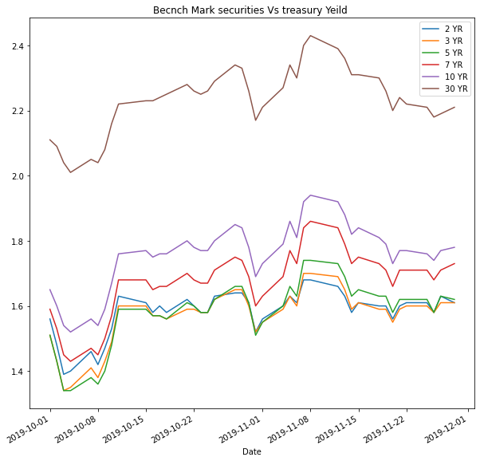

```python
#'Graph the 6 benchmark securities for the 2 months on 1 plot.  That means the 6 yield series are overlaid on the same area.Add a legend
%matplotlib inline
us_treasury.plot(
figsize=(10,10),
legend=True,
title="Becnch Mark securities Vs treasury Yeild ",
sharex=False,
)
```

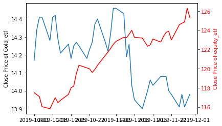

```python
#'On a separate graph, plot the gold ETF prices (not returns!) for the 2 months.  Use the left-side axis for the price label
#'On the same graph, plot the equity ETF prices (not returns!) for the 2 months.  Be sure to use a separate scale, and the right-side axis for the price label
fig = plt.figure()
ax1 = fig.add_subplot(111)
ax1.plot(gold_etf.index, gold_etf.Close)
ax1.set_ylabel('Close Price of Gold_etf')

ax2 = ax1.twinx()
ax2.plot(equity_etf.index,equity_etf.Close , 'r-')
ax2.set_ylabel('Close Price of equity_etf', color='r')
for tl in ax2.get_yticklabels():
    tl.set_color('r')
```

# 'Fitting the Yield Curve

Q)Use either Nelson-Siegel, or Nelson-Siegel-Svensson to fit the Yield Curve. Write out the equation.

the Nelson-Siegel, or Nelson-Siegel-Svensson is used to plot the zero coupen rates and implied forward rate for different yield to maturities the equation is given by f (t) = β0 + β1 *exp(-t / Ʈ1) + β2* exp(-t / Ʈ1) *(-t / Ʈ1) + β3* exp(-t / Ʈ2) *(-t / Ʈ2) and zero coupen rate is given by r(t) = β0 + (β1 + β2 )* (1- exp-(t / Ʈ1))/( t /Ʈ1) — β2 *exp(-t / Ʈ1)) + β3* (1- exp-(t / Ʈ2))/( t / Ʈ2) — β3 * exp(-t / Ʈ2)) β0, β1, β2 and Ʈ : model parameters that are to be estimated. These are parameters respectively for long term rate, short term rate, slope and degree of hump. Ʈ2 and β3 explain the hump and level and direction of the hump in the curve

```python
!pip install nelson-siegel-svensson
import numpy as np
```

```python
from nelson_siegel_svensson import NelsonSiegelSvenssonCurve, NelsonSiegelCurve
from nelson_siegel_svensson.calibrate import calibrate_ns_ols, calibrate_nss_ols
```

```python
from nelson_siegel_svensson.calibrate import calibrate_ns_ols
```

```python
#  below are spot rate derived from the mean part rate for octember data for US TREASURY
y_oct=[1.550754949,1.527410018,1.524457722,1.618469706,1.715404972,2.278495244]
y_oct=np.array(y_oct)
y_oct
```

```
array([1.55075495, 1.52741002, 1.52445772, 1.61846971, 1.71540497,
       2.27849524])
```

```python
t = np.array([ 2.0, 3.0,5.0,7.0, 10.0, 30.0])
```

```python
curve_fit1, status1 = calibrate_nss_ols(t,y_oct) #NS model calibrate
```

```python
NSS_ZC = NelsonSiegelSvenssonCurve.zero(curve_fit1,t)
print(NSS_ZC)
```

```
[1.55537396 1.51672992 1.53595527 1.61192476 1.7165098  2.27849889]
```

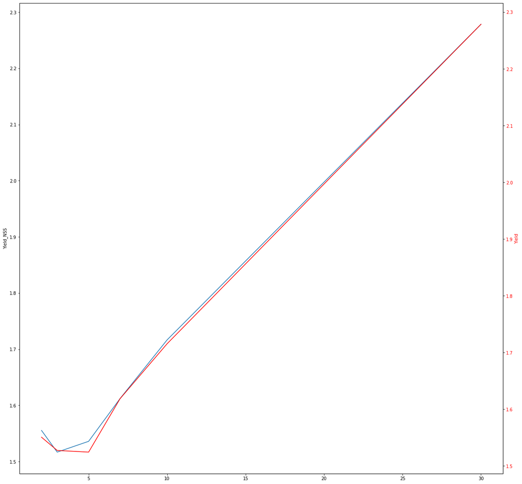

```python
fig = plt.figure()
ax1 = fig.add_subplot(111)
ax1.plot(t, NSS_ZC)
ax1.set_ylabel('Yield_NSS')

ax2 = ax1.twinx()
ax2.plot(t,y_oct , 'r-')
ax2.set_ylabel('Yield', color='r')
for tl in ax2.get_yticklabels():
    tl.set_color('r')
```

```python
import numpy as np
from nelson_siegel_svensson.calibrate import calibrate_ns_ols

t = np.array([2.0, 3.0,5.0,7.0, 10.0, 30.0])
y = np.array([1.550754949,1.527410018,1.524457722,1.618469706,1.715404972,2.278495244])

curve1, status = calibrate_ns_ols(t, y, tau0=1.0)
assert status.success
print(curve1)
```

```
NelsonSiegelCurve(beta0=2.7115772978152286, beta1=-1.0019095138619658, beta2=-2.0910709365097073, tau=4.225457478124434)
```

```python
#   below are spot rate derived from the mean part rate for November data for US TREASURY

y_nov=[1.612996538,1.612339562,1.640360006,1.740939947,1.821201195,2.364414564]
y_nov=np.array(y_nov)
y_nov
t = np.array([ 2.0, 3.0,5.0,7.0, 10.0, 30.0])
curve_fit_nov, status2 = calibrate_nss_ols(t,y_nov) #NS model calibrate
NSS_ZC_nov = NelsonSiegelSvenssonCurve.zero(curve_fit_nov,t)
print(NSS_ZC_nov)
```

```
[1.61720234 1.60261067 1.65097826 1.73469767 1.82235292 2.36440996]
```

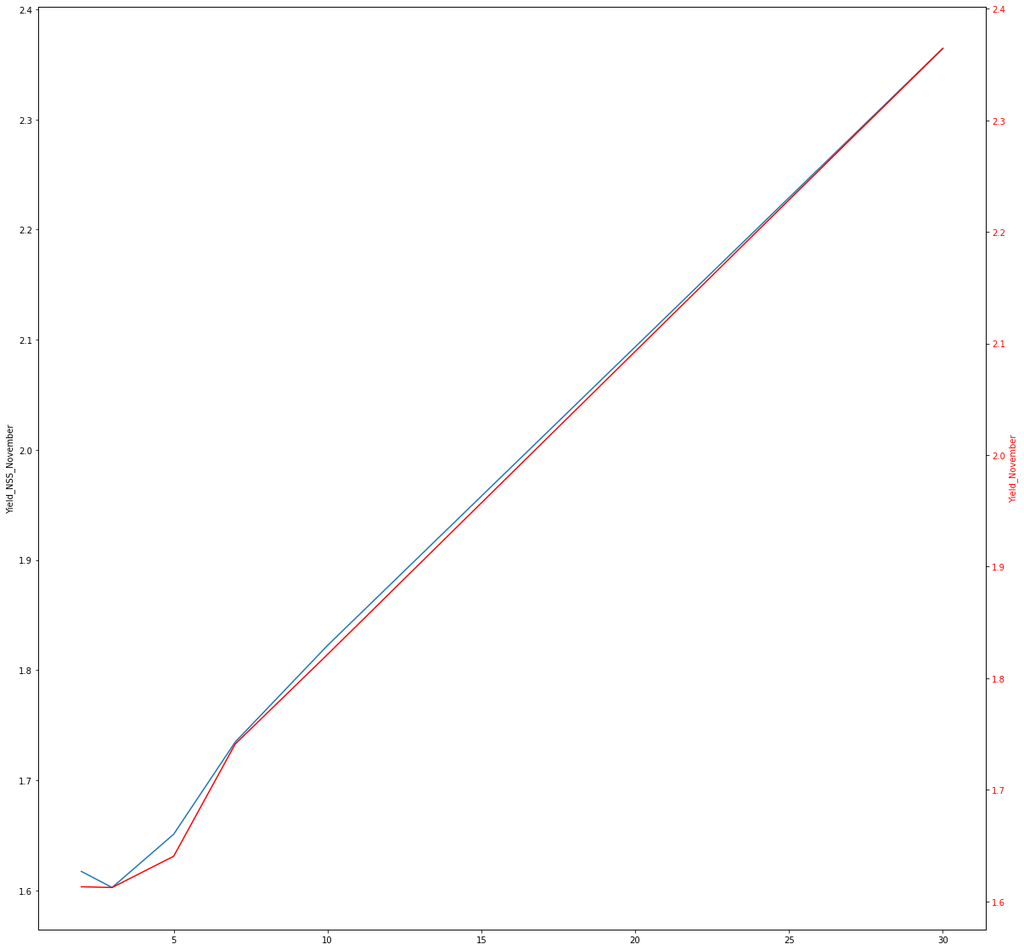

```python
fig = plt.figure()
ax1 = fig.add_subplot(111)
ax1.plot(t, NSS_ZC_nov)
ax1.set_ylabel('Yield_NSS_November')

ax2 = ax1.twinx()
ax2.plot(t,y_nov , 'r-')
ax2.set_ylabel('Yield_November', color='r')
for tl in ax2.get_yticklabels():
    tl.set_color('r')
```

# findings from yield curve fitting

```python
import numpy as np
from nelson_siegel_svensson.calibrate import calibrate_ns_ols

t = np.array([2.0, 3.0,5.0,7.0, 10.0, 30.0])
y = np.array([1.612996538,1.612339562,1.640360006,1.740939947,1.821201195,2.364414564])

curve, status = calibrate_ns_ols(t, y, tau0=1.0)
assert status.success
print(curve)
```

```
NelsonSiegelCurve(beta0=2.8482857333199068, beta1=-1.2003905433058992, beta2=-1.6214909446121324, tau=5.220914324425495)
```

Parameters for October and November 2019 are as follow: October 2019 NelsonSiegelCurve(beta0=2.7115772978152286, beta1=-1.0019095138619658, beta2=-2.0910709365097073, tau=4.225457478124434)

November 2019 NelsonSiegelCurve(beta0=2.8482857333199068, beta1=-1.2003905433058992, beta2=-1.6214909446121324, tau=5.220914324425495)

# Modeling Prices

```python
# adjuste closing price chosen for time series modelling of gold etf data
gold_etf_ts=gold_etf[['Adj Close']]
```

```python
gold_etf_ts
```

| Date | Adj Close |
| --- | --- |
| 2019-10-01 | 14.17 |
| 2019-10-02 | 14.34 |
| 2019-10-03 | 14.41 |
| 2019-10-04 | 14.41 |
| 2019-10-07 | 14.28 |
| 2019-10-08 | 14.41 |
| 2019-10-09 | 14.42 |
| 2019-10-10 | 14.29 |
| 2019-10-11 | 14.21 |
| 2019-10-14 | 14.26 |
| 2019-10-15 | 14.18 |
| 2019-10-16 | 14.25 |
| 2019-10-17 | 14.27 |
| 2019-10-18 | 14.25 |
| 2019-10-21 | 14.18 |
| 2019-10-22 | 14.23 |
| 2019-10-23 | 14.27 |
| 2019-10-24 | 14.37 |
| 2019-10-25 | 14.40 |
| 2019-10-28 | 14.27 |
| 2019-10-29 | 14.22 |
| 2019-10-30 | 14.32 |
| 2019-10-31 | 14.46 |
| 2019-11-01 | 14.46 |
| 2019-11-04 | 14.43 |
| 2019-11-05 | 14.19 |
| 2019-11-06 | 14.26 |
| 2019-11-07 | 14.03 |
| 2019-11-08 | 13.95 |
| 2019-11-11 | 13.90 |
| 2019-11-12 | 13.95 |
| 2019-11-13 | 14.00 |
| 2019-11-14 | 14.06 |
| 2019-11-15 | 14.03 |
| 2019-11-18 | 14.08 |
| 2019-11-19 | 14.08 |
| 2019-11-20 | 14.08 |
| 2019-11-21 | 14.00 |
| 2019-11-22 | 13.98 |
| 2019-11-25 | 13.91 |
| 2019-11-26 | 13.98 |
| 2019-11-27 | 13.91 |
| 2019-11-29 | 13.98 |

```python
# checking for stationarity an dimporting tools to plot acf and pacf
from statsmodels.graphics.tsaplots import plot_acf, plot_pacf
from statsmodels.tsa.stattools import adfuller, kpss
```

```python
# renaming columns as per question
gold_etf_ts.rename(columns={'Adj Close':'price'},inplace=True)
```

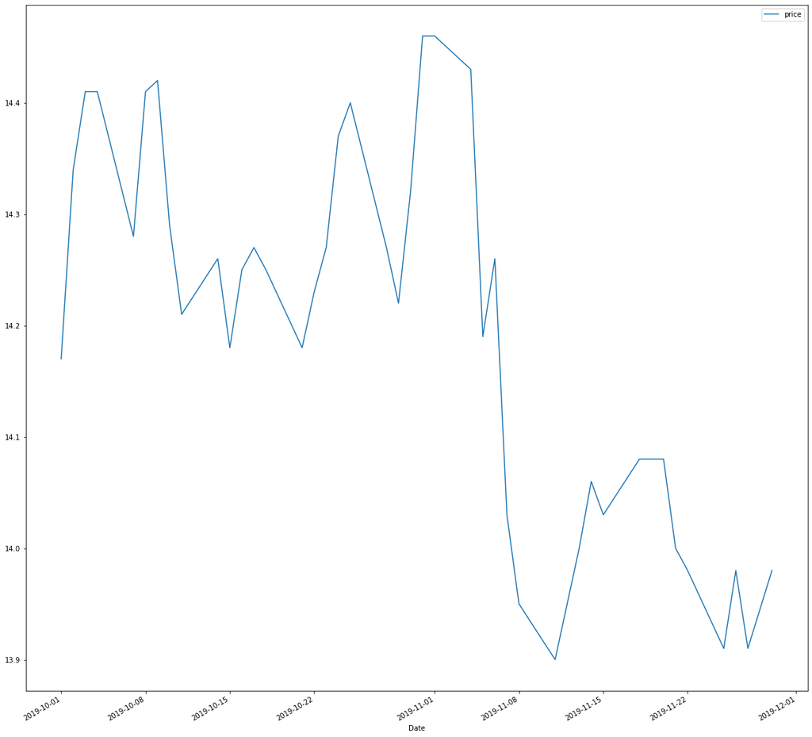

```python
gold_etf_ts.plot()
# we can see there is downword trend  so time series may not be statioanry
```

```python
#Check for stationariy for series
def adf_stationarity_test(price):
    indices= ['Test Statistic', 'p-value','no of Lags Used', 'no of Observations Used']
    adf_sta_test=adfuller(price,autolag="AIC")
    print(adf_sta_test)
    result=pd.Series(adf_sta_test[0:4],index=indices)
    for key,value in adf_sta_test[4].items():
        print(key)
        print(value)
        result[f'Critical value({key})']=value

    return result
adf_stationarity_test(gold_etf_ts.price)
#The null hypothesis of the ADF test states that the time series is not stationary. hence series is not stationary
```

```
(-1.4990012995065827, 0.5340053237867125, 0, 42, {'1%': -3.596635636000432, '5%': -2.933297331821618, '10%': -2.6049909750566895}, -63.817208438896046)
1%
-3.596635636000432
5%
-2.933297331821618
10%
-2.6049909750566895
```

```
Test Statistic             -1.499001
p-value                     0.534005
no of Lags Used             0.000000
no of Observations Used    42.000000
Critical value(1%)         -3.596636
Critical value(5%)         -2.933297
Critical value(10%)        -2.604991
dtype: float64
```

```python
# calculating first difference to make series statioanry
gold_etf_ts_diff=gold_etf_ts.diff().dropna()
```

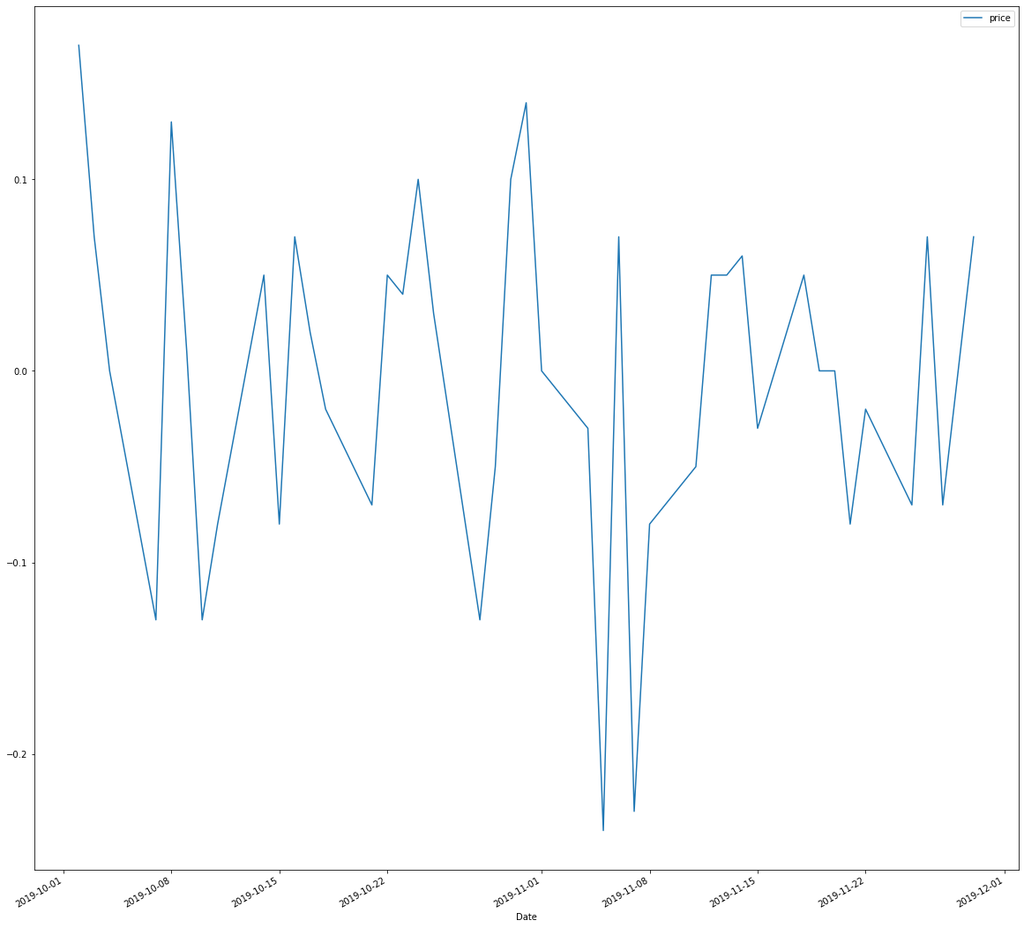

```python
# plots shwos time series stationary
gold_etf_ts_diff.plot()
```

```python
gold_etf_ts_diff=gold_etf_ts_diff.dropna()
def adf_stationarity_test(price):
    indices= ['Test Statistic', 'p-value','no of Lags Used', 'no of Observations Used']
    adf_sta_test=adfuller(price,autolag="AIC")
    result=pd.Series(adf_sta_test[0:4],index=indices)
    for key,value in adf_sta_test[4].items():
        print(key)
        print(value)
        result[f'Critical value({key})']=value

    return result
adf_stationarity_test(gold_etf_ts_diff.price)
#The null hypothesis of the ADF test states that the time series is not stationary. now p value is less than 5% hence series is  stationary
```

```
1%
-3.610399601308181
5%
-2.939108945868946
10%
-2.6080629651545038
```

```
Test Statistic             -4.648424
p-value                     0.000105
no of Lags Used             2.000000
no of Observations Used    39.000000
Critical value(1%)         -3.610400
Critical value(5%)         -2.939109
Critical value(10%)        -2.608063
dtype: float64
```

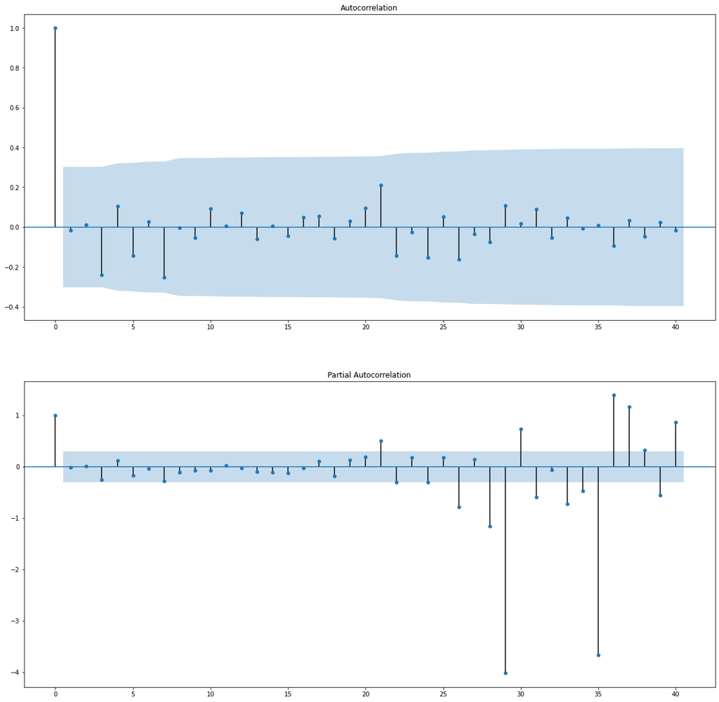

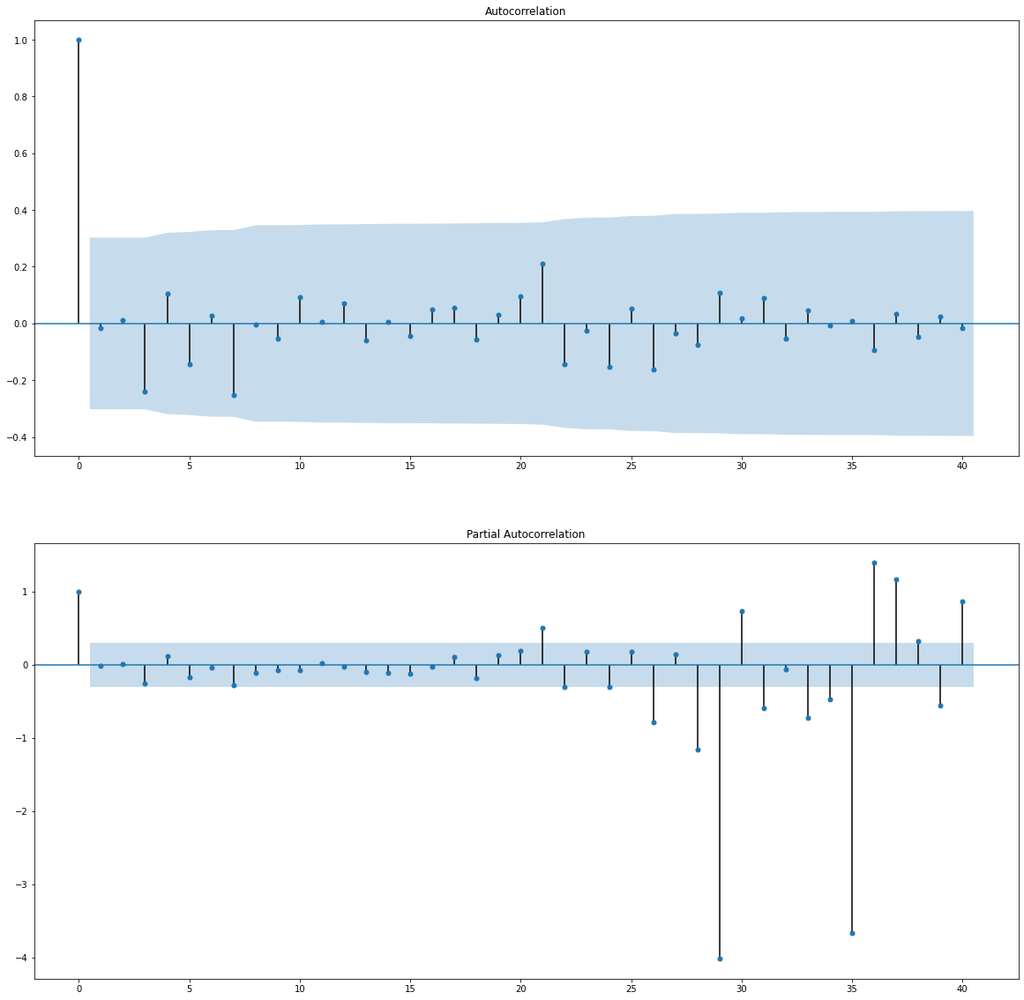

```python
#plotting acf and pacf plots

N_LAGS=40
SIGNIFICANCE_LEVEL = 0.05
fig, ax = plt.subplots(2, 1)
plot_acf(
gold_etf_ts_diff.price,ax=ax[0],lags=N_LAGS,alpha=SIGNIFICANCE_LEVEL
)
plot_pacf(
gold_etf_ts_diff.price,ax=ax[1],lags=N_LAGS,alpha=SIGNIFICANCE_LEVEL
)
```

```python
from statsmodels.tsa.arima_model import ARIMA
import statsmodels.api as sm
from statsmodels.graphics.tsaplots import plot_acf
from statsmodels.stats.diagnostic import acorr_ljungbox
import scipy.stats as scs

#ARIMA(0,1,1)
arima = ARIMA(gold_etf_ts, order=(0, 1, 1)).fit(disp=0)
arima.summary()
```

ARIMA Model Results

| Dep. Variable: | D.price | No. Observations: | 42 |
| --- | --- | --- | --- |
| Model: | ARIMA(0, 1, 1) | Log Likelihood | 41.729 |
| Method: | css-mle | S.D. of innovations | 0.090 |
| Date: | Sun, 10 Jan 2021 | AIC | -77.458 |
| Time: | 11:44:37 | BIC | -72.245 |
| Sample: | 1 | HQIC | -75.547 |

|  | coef | std err | z | P>\|z\| | [0.025 | 0.975] |
| --- | --- | --- | --- | --- | --- | --- |
| const | -0.0046 | 0.014 | -0.341 | 0.733 | -0.031 | 0.022 |
| ma.L1.D.price | -0.0193 | 0.162 | -0.119 | 0.906 | -0.337 | 0.299 |

Roots

|  | Real | Imaginary | Modulus | Frequency |
| --- | --- | --- | --- | --- |
| MA.1 | 51.9072 | +0.0000j | 51.9072 | 0.0000 |

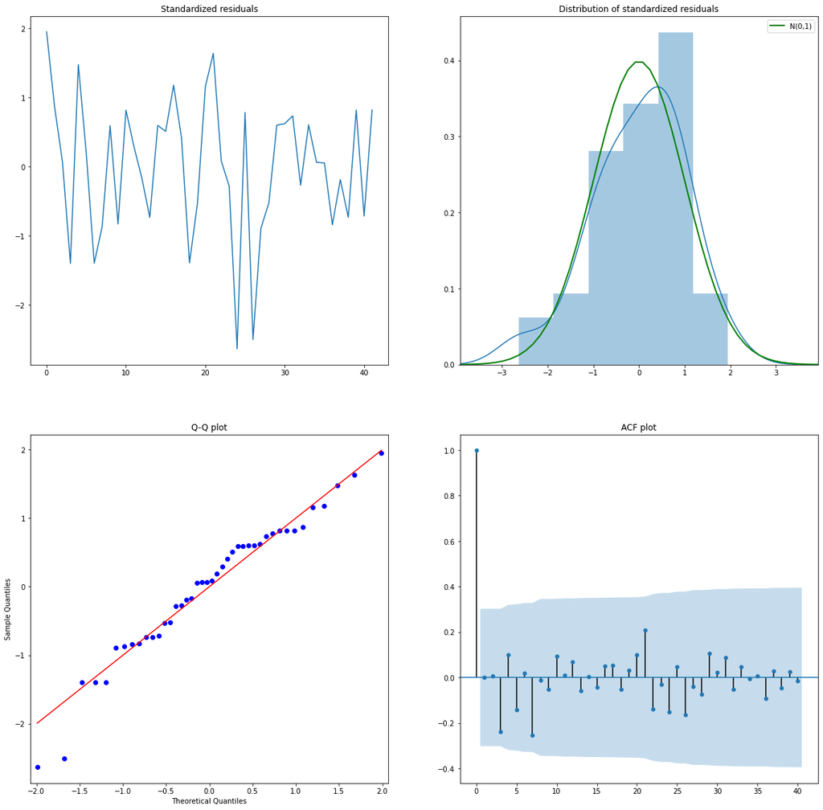

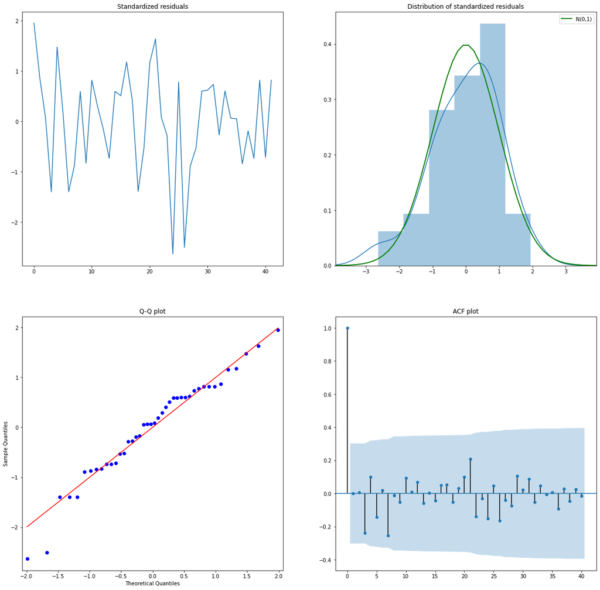

```python
#  analysing  where the model is good fit or not
def arima_diagnostics(resids, n_lags=40):
 # create placeholder subplots
     fig, ((ax1, ax2), (ax3, ax4)) = plt.subplots(2, 2)
     r = resids
     resids = (r - np.nanmean(r)) / np.nanstd(r)
     resids_nonmissing = resids[~(np.isnan(resids))]
     # residuals over time
     sns.lineplot(x=np.arange(len(resids)), y=resids, ax=ax1)
     ax1.set_title('Standardized residuals')
     # distribution of residuals
     x_lim = (-1.96 * 2, 1.96 * 2)
     r_range = np.linspace(x_lim[0], x_lim[1])
     norm_pdf = scs.norm.pdf(r_range)
     sns.distplot(resids_nonmissing, hist=True, kde=True,
     norm_hist=True, ax=ax2)
     ax2.plot(r_range, norm_pdf, 'g', lw=2, label='N(0,1)')
     ax2.set_title('Distribution of standardized residuals')
     ax2.set_xlim(x_lim)
     ax2.legend()
     # Q-Q plot
     qq = sm.qqplot(resids_nonmissing, line='s', ax=ax3)
     ax3.set_title('Q-Q plot')
#     Time Series Modeling Chapter 3
#     [ 117 ]
     # ACF plot
     plot_acf(resids, ax=ax4, lags=n_lags, alpha=0.05)
     ax4.set_title('ACF plot')
     return fig
#Test the residuals of the fitted ARIM
arima_diagnostics(arima.resid, 40)
```

```python
#errors distribution is left skewed so model is not good fit
```

[output not shown]

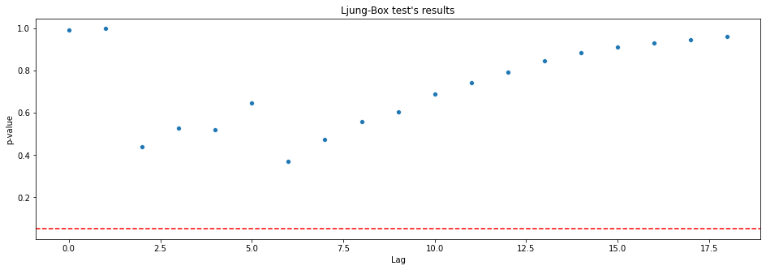

```python
#8. Apply the Ljung-Box test for no autocorrelation in the residuals and plot the
#results:
ljung_box_results = acorr_ljungbox(arima.resid)
fig, ax = plt.subplots(1, figsize=[16, 5])
sns.scatterplot(x=range(len(ljung_box_results[1])),
 y=ljung_box_results[1],ax=ax)
ax.axhline(0.05, ls='--', c='r')
ax.set(title="Ljung-Box test's results",xlabel='Lag',ylabel='p-value')
```

# automatic fitting of model

```python
!pip install pmdarima
```

[output not shown]

```python
import pmdarima as pm
```

```python
model = pm.auto_arima(gold_etf_ts,
 error_action='ignore',
 suppress_warnings=True,
 seasonal=False)
model.summary()
```

SARIMAX Results

| Dep. Variable: | y | No. Observations: | 43 |
| --- | --- | --- | --- |
| Model: | SARIMAX(0, 1, 0) | Log Likelihood | 41.668 |
| Date: | Sun, 10 Jan 2021 | AIC | -81.337 |
| Time: | 12:24:05 | BIC | -79.599 |
| Sample: | 0 | HQIC | -80.700 |
|  | - 43 |  |  |
| Covariance Type: | opg |  |  |

|  | coef | std err | z | P>\|z\| | [0.025 | 0.975] |
| --- | --- | --- | --- | --- | --- | --- |
| sigma2 | 0.0080 | 0.002 | 4.959 | 0.000 | 0.005 | 0.011 |

| Ljung-Box (Q): | 31.91 | Jarque-Bera (JB): | 2.28 |
| --- | --- | --- | --- |
| Prob(Q): | 0.82 | Prob(JB): | 0.32 |
| Heteroskedasticity (H): | 0.37 | Skew: | -0.56 |
| Prob(H) (two-sided): | 0.07 | Kurtosis: | 3.23 |

Warnings:  
[1] Covariance matrix calculated using the outer product of gradients (complex-step).

```python
model = pm.auto_arima(gold_etf_ts.price,
 error_action='ignore',
 suppress_warnings=True,
 seasonal=False,
 stepwise=False,
 approximation=False,
 n_jobs=-1)
model.summary()
```

SARIMAX Results

| Dep. Variable: | y | No. Observations: | 43 |
| --- | --- | --- | --- |
| Model: | SARIMAX(0, 1, 0) | Log Likelihood | 41.722 |
| Date: | Sun, 10 Jan 2021 | AIC | -79.444 |
| Time: | 12:24:13 | BIC | -75.968 |
| Sample: | 0 | HQIC | -78.170 |
|  | - 43 |  |  |
| Covariance Type: | opg |  |  |

|  | coef | std err | z | P>\|z\| | [0.025 | 0.975] |
| --- | --- | --- | --- | --- | --- | --- |
| intercept | -0.0045 | 0.015 | -0.303 | 0.762 | -0.034 | 0.025 |
| sigma2 | 0.0080 | 0.002 | 4.488 | 0.000 | 0.005 | 0.012 |

| Ljung-Box (Q): | 31.91 | Jarque-Bera (JB): | 2.28 |
| --- | --- | --- | --- |
| Prob(Q): | 0.82 | Prob(JB): | 0.32 |
| Heteroskedasticity (H): | 0.37 | Skew: | -0.56 |
| Prob(H) (two-sided): | 0.08 | Kurtosis: | 3.23 |

Warnings:  
[1] Covariance matrix calculated using the outer product of gradients (complex-step).

```python
mod = sm.tsa.statespace.SARIMAX(gold_etf_ts.price, trend='n', order=(0,1,0))
```

```python
mod
```

```
<statsmodels.tsa.statespace.sarimax.SARIMAX at 0x17f07585400>
```

```python
results=mod.fit()
```

```python
results.summary()
```

SARIMAX Results

| Dep. Variable: | price | No. Observations: | 43 |
| --- | --- | --- | --- |
| Model: | SARIMAX(0, 1, 0) | Log Likelihood | 41.668 |
| Date: | Sun, 10 Jan 2021 | AIC | -81.337 |
| Time: | 12:27:21 | BIC | -79.599 |
| Sample: | 0 | HQIC | -80.700 |
|  | - 43 |  |  |
| Covariance Type: | opg |  |  |

|  | coef | std err | z | P>\|z\| | [0.025 | 0.975] |
| --- | --- | --- | --- | --- | --- | --- |
| sigma2 | 0.0080 | 0.002 | 4.959 | 0.000 | 0.005 | 0.011 |

| Ljung-Box (Q): | 31.91 | Jarque-Bera (JB): | 2.28 |
| --- | --- | --- | --- |
| Prob(Q): | 0.82 | Prob(JB): | 0.32 |
| Heteroskedasticity (H): | 0.37 | Skew: | -0.56 |
| Prob(H) (two-sided): | 0.07 | Kurtosis: | 3.23 |

Warnings:  
[1] Covariance matrix calculated using the outer product of gradients (complex-step).

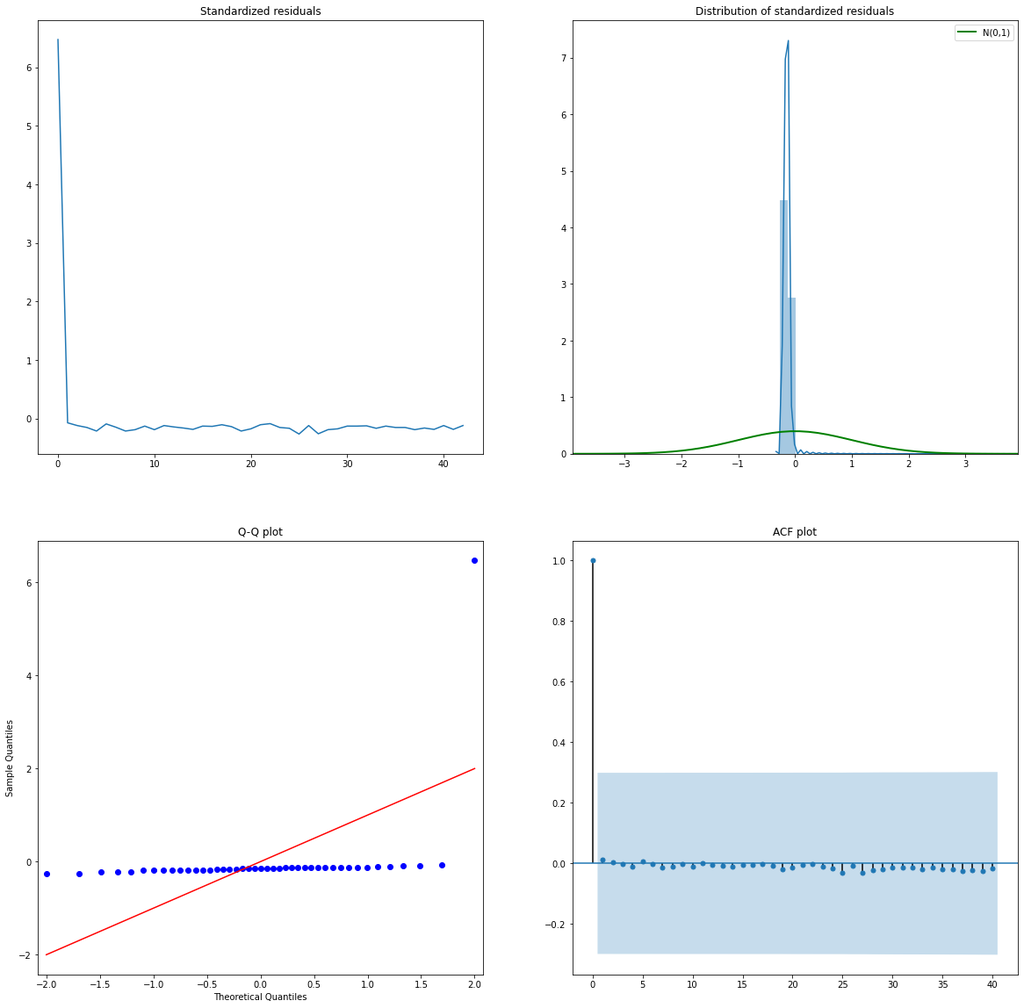

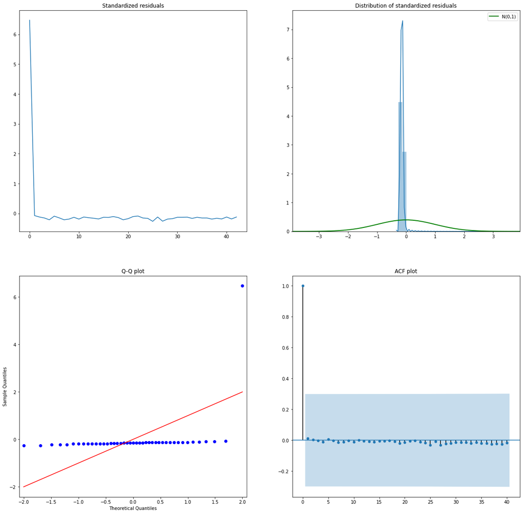

```python
def arima_diagnostics(resids, n_lags=40):
 # create placeholder subplots
     fig, ((ax1, ax2), (ax3, ax4)) = plt.subplots(2, 2)
     r = resids
     resids = (r - np.nanmean(r)) / np.nanstd(r)
     resids_nonmissing = resids[~(np.isnan(resids))]
     # residuals over time
     sns.lineplot(x=np.arange(len(resids)), y=resids, ax=ax1)
     ax1.set_title('Standardized residuals')
     # distribution of residuals
     x_lim = (-1.96 * 2, 1.96 * 2)
     r_range = np.linspace(x_lim[0], x_lim[1])
     norm_pdf = scs.norm.pdf(r_range)
     sns.distplot(resids_nonmissing, hist=True, kde=True,
     norm_hist=True, ax=ax2)
     ax2.plot(r_range, norm_pdf, 'g', lw=2, label='N(0,1)')
     ax2.set_title('Distribution of standardized residuals')
     ax2.set_xlim(x_lim)
     ax2.legend()
     # Q-Q plot
     qq = sm.qqplot(resids_nonmissing, line='s', ax=ax3)
     ax3.set_title('Q-Q plot')
#     Time Series Modeling Chapter 3
#     [ 117 ]
     # ACF plot
     plot_acf(resids, ax=ax4, lags=n_lags, alpha=0.05)
     ax4.set_title('ACF plot')
     return fig
#Test the residuals of the fitted ARIM
arima_diagnostics(results.resid, 40)
```

# from GOLD_ETF dataset we can conclude that the process is random walk

and looking data set no of rows, we are not sure about seasonality hence we cant make predictions of future prices

# modelling equity etf

```python
equity_etf_ts=equity_etf[['Adj Close']]
equity_etf_ts
equity_etf_ts.rename(columns={'Adj Close':'price'},inplace=True)
```

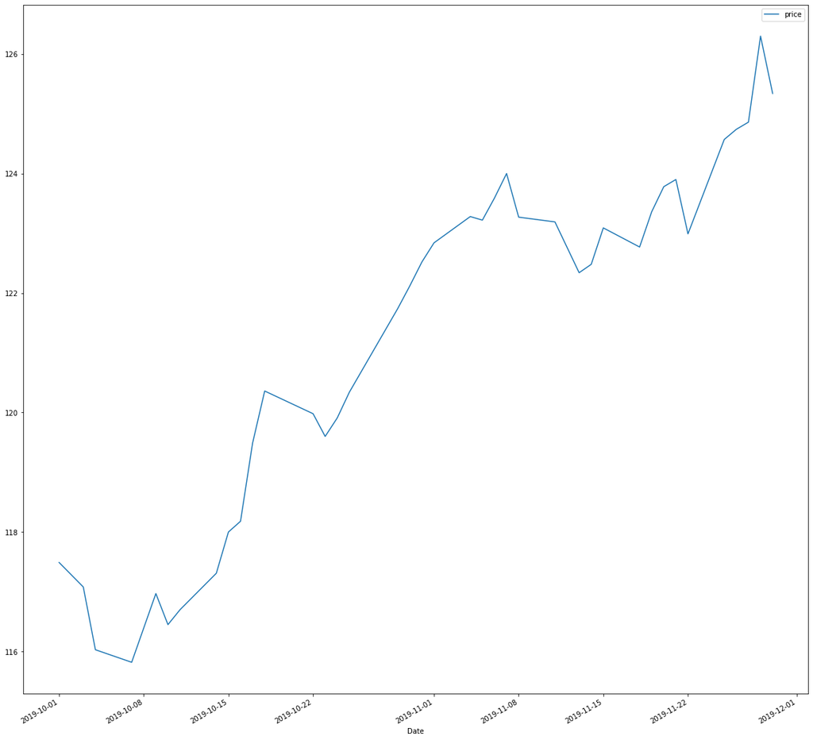

```python
equity_etf_ts.plot() # it may be   upward  trending series
# lets check for stationarity
```

```python
def adf_stationarity_test(price):
    indices= ['Test Statistic', 'p-value','no of Lags Used', 'no of Observations Used']
    adf_sta_test=adfuller(price,autolag="AIC")
    result=pd.Series(adf_sta_test[0:4],index=indices)
    for key,value in adf_sta_test[4].items():
        print(key)
        print(value)
        result[f'Critical value({key})']=value

    return result
adf_stationarity_test(equity_etf_ts.price)
```

```
1%
-3.6155091011809297
5%
-2.941262357486514
10%
-2.6091995013850418
```

```
Test Statistic             -0.601278
p-value                     0.870693
no of Lags Used             0.000000
no of Observations Used    38.000000
Critical value(1%)         -3.615509
Critical value(5%)         -2.941262
Critical value(10%)        -2.609200
dtype: float64
```

```python
# not  stationary taking frist difference
equity_etf_ts_diff=equity_etf_ts.diff().dropna()
```

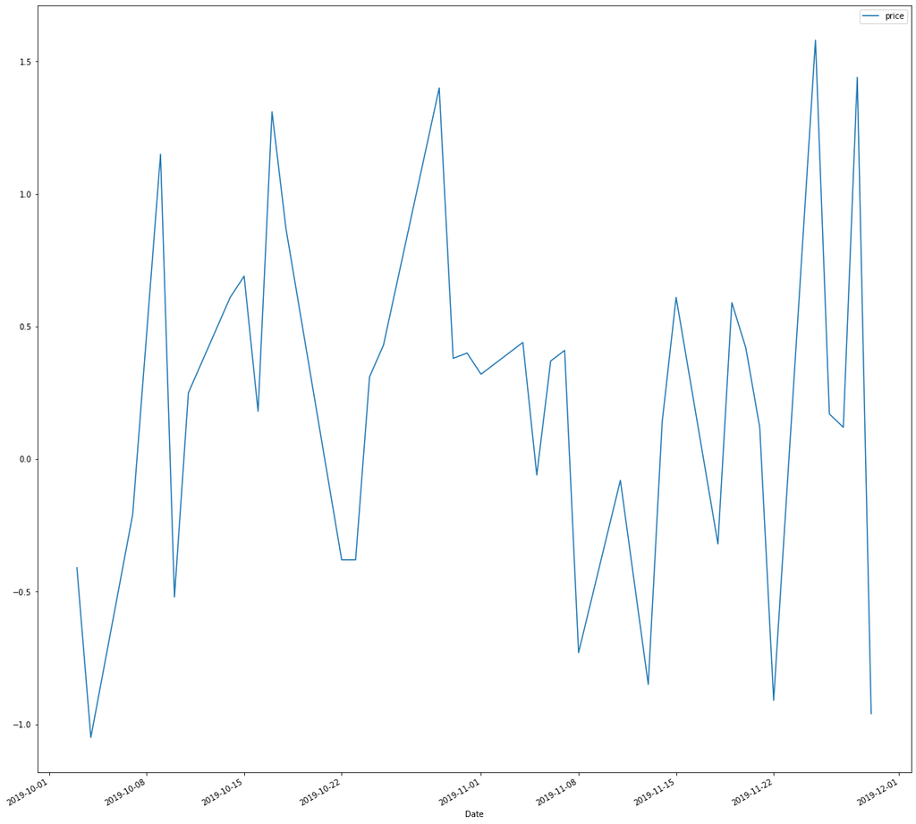

```python
equity_etf_ts_diff.plot()
```

```python
def adf_stationarity_test(price):
    indices= ['Test Statistic', 'p-value','no of Lags Used', 'no of Observations Used']
    adf_sta_test=adfuller(price,autolag="AIC")
    result=pd.Series(adf_sta_test[0:4],index=indices)
    for key,value in adf_sta_test[4].items():
        print(key)
        print(value)
        result[f'Critical value({key})']=value

    return result
adf_stationarity_test(equity_etf_ts_diff.price)
```

```
1%
-3.6209175221605827
5%
-2.9435394610388332
10%
-2.6104002410518627
```

```
Test Statistic            -6.311838e+00
p-value                    3.220392e-08
no of Lags Used            0.000000e+00
no of Observations Used    3.700000e+01
Critical value(1%)        -3.620918e+00
Critical value(5%)        -2.943539e+00
Critical value(10%)       -2.610400e+00
dtype: float64
```

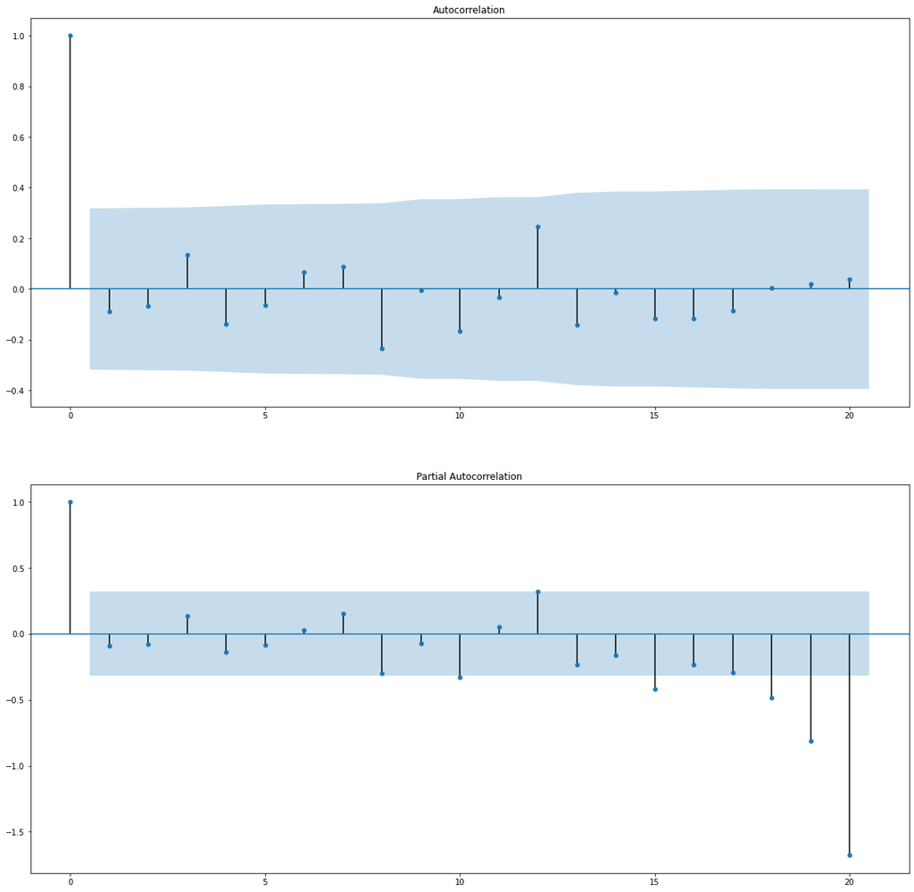

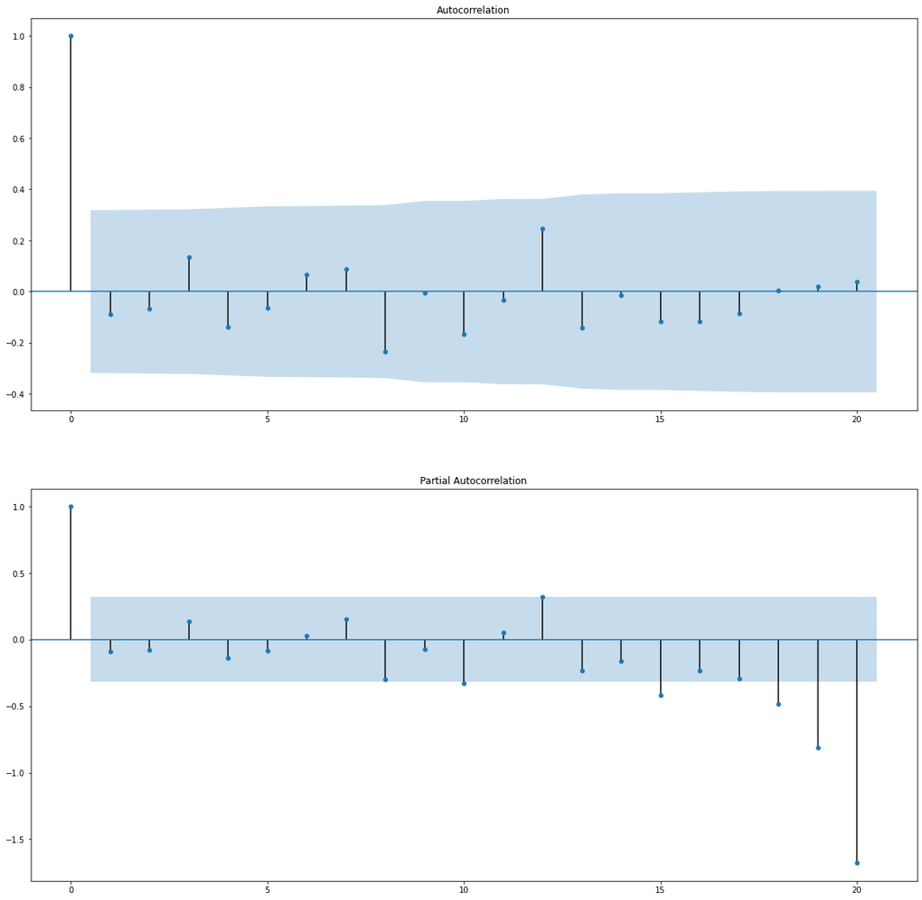

```python
#plotting acf and pacf plots

N_LAGS=20
SIGNIFICANCE_LEVEL = 0.05
fig, ax = plt.subplots(2, 1)
plot_acf(
equity_etf_ts_diff.price,ax=ax[0],lags=N_LAGS,alpha=SIGNIFICANCE_LEVEL
)
plot_pacf(
equity_etf_ts_diff.price,ax=ax[1],lags=N_LAGS,alpha=SIGNIFICANCE_LEVEL
)
```

```python
model = pm.auto_arima(equity_etf_ts,
 error_action='ignore',
 suppress_warnings=True,
 seasonal=True)
model.summary()
```

SARIMAX Results

| Dep. Variable: | y | No. Observations: | 39 |
| --- | --- | --- | --- |
| Model: | SARIMAX(0, 1, 0) | Log Likelihood | -38.410 |
| Date: | Sun, 10 Jan 2021 | AIC | 80.821 |
| Time: | 13:24:45 | BIC | 84.096 |
| Sample: | 0 | HQIC | 81.986 |
|  | - 39 |  |  |
| Covariance Type: | opg |  |  |

|  | coef | std err | z | P>\|z\| | [0.025 | 0.975] |
| --- | --- | --- | --- | --- | --- | --- |
| intercept | 0.2066 | 0.108 | 1.913 | 0.056 | -0.005 | 0.418 |
| sigma2 | 0.4421 | 0.114 | 3.876 | 0.000 | 0.219 | 0.666 |

| Ljung-Box (Q): | 43.48 | Jarque-Bera (JB): | 0.30 |
| --- | --- | --- | --- |
| Prob(Q): | 0.21 | Prob(JB): | 0.86 |
| Heteroskedasticity (H): | 1.24 | Skew: | 0.07 |
| Prob(H) (two-sided): | 0.71 | Kurtosis: | 2.59 |

Warnings:  
[1] Covariance matrix calculated using the outer product of gradients (complex-step).

# from Equity_ETF dataset we can conclude that the process is random walk

and looking data set no of rows, we are not sure about seasonality hence we cant make predictions of future prices

```python
model = pm.auto_arima(gold_etf_ts.price,
 error_action='ignore',
 suppress_warnings=True,
 seasonal=True,
 stepwise=False,
 approximation=False,
 n_jobs=-1)
model.summary()
```

SARIMAX Results

| Dep. Variable: | y | No. Observations: | 43 |
| --- | --- | --- | --- |
| Model: | SARIMAX(0, 1, 0) | Log Likelihood | 41.722 |
| Date: | Sun, 10 Jan 2021 | AIC | -79.444 |
| Time: | 13:26:44 | BIC | -75.968 |
| Sample: | 0 | HQIC | -78.170 |
|  | - 43 |  |  |
| Covariance Type: | opg |  |  |

|  | coef | std err | z | P>\|z\| | [0.025 | 0.975] |
| --- | --- | --- | --- | --- | --- | --- |
| intercept | -0.0045 | 0.015 | -0.303 | 0.762 | -0.034 | 0.025 |
| sigma2 | 0.0080 | 0.002 | 4.488 | 0.000 | 0.005 | 0.012 |

| Ljung-Box (Q): | 31.91 | Jarque-Bera (JB): | 2.28 |
| --- | --- | --- | --- |
| Prob(Q): | 0.82 | Prob(JB): | 0.32 |
| Heteroskedasticity (H): | 0.37 | Skew: | -0.56 |
| Prob(H) (two-sided): | 0.08 | Kurtosis: | 3.23 |

Warnings:  
[1] Covariance matrix calculated using the outer product of gradients (complex-step).

```python
us_treasury.to_csv("Us.csv")
```

```python
gold_etf
```

| Date | Open | High | Low | Close | Adj Close | Volume | Daily_Returns |
| --- | --- | --- | --- | --- | --- | --- | --- |
| 2019-10-01 | 14.01 | 14.23 | 13.98 | 14.17 | 14.17 | 27078500 | 0.496452 |
| 2019-10-02 | 14.29 | 14.40 | 14.25 | 14.34 | 14.34 | 25880200 | 1.199718 |
| 2019-10-03 | 14.34 | 14.54 | 14.34 | 14.41 | 14.41 | 30910300 | 0.488143 |
| 2019-10-04 | 14.36 | 14.44 | 14.33 | 14.41 | 14.41 | 26357900 | 0.000000 |
| 2019-10-07 | 14.33 | 14.39 | 14.23 | 14.28 | 14.28 | 22807800 | -0.902152 |
| 2019-10-08 | 14.42 | 14.44 | 14.32 | 14.41 | 14.41 | 41484700 | 0.910365 |
| 2019-10-09 | 14.43 | 14.47 | 14.37 | 14.42 | 14.42 | 17320400 | 0.069398 |
| 2019-10-10 | 14.37 | 14.37 | 14.26 | 14.29 | 14.29 | 18505700 | -0.901526 |
| 2019-10-11 | 14.20 | 14.22 | 14.10 | 14.21 | 14.21 | 31670800 | -0.559832 |
| 2019-10-14 | 14.26 | 14.29 | 14.24 | 14.26 | 14.26 | 6433300 | 0.351866 |
| 2019-10-15 | 14.23 | 14.24 | 14.13 | 14.18 | 14.18 | 17750000 | -0.561009 |
| 2019-10-16 | 14.23 | 14.26 | 14.17 | 14.25 | 14.25 | 12967200 | 0.493651 |
| 2019-10-17 | 14.25 | 14.32 | 14.25 | 14.27 | 14.27 | 10201900 | 0.140354 |
| 2019-10-18 | 14.26 | 14.28 | 14.24 | 14.25 | 14.25 | 7902900 | -0.140157 |
| 2019-10-21 | 14.27 | 14.29 | 14.17 | 14.18 | 14.18 | 7589600 | -0.491226 |
| 2019-10-22 | 14.22 | 14.24 | 14.18 | 14.23 | 14.23 | 7297800 | 0.352604 |
| 2019-10-23 | 14.26 | 14.31 | 14.26 | 14.27 | 14.27 | 10742100 | 0.281103 |
| 2019-10-24 | 14.31 | 14.38 | 14.30 | 14.37 | 14.37 | 12788800 | 0.700767 |
| 2019-10-25 | 14.50 | 14.50 | 14.35 | 14.40 | 14.40 | 16223100 | 0.208766 |
| 2019-10-28 | 14.34 | 14.34 | 14.25 | 14.27 | 14.27 | 13739900 | -0.902772 |
| 2019-10-29 | 14.21 | 14.27 | 14.19 | 14.22 | 14.22 | 13785900 | -0.350387 |
| 2019-10-30 | 14.26 | 14.32 | 14.16 | 14.32 | 14.32 | 19324300 | 0.703231 |
| 2019-10-31 | 14.41 | 14.48 | 14.40 | 14.46 | 14.46 | 17305400 | 0.977656 |
| 2019-11-01 | 14.44 | 14.50 | 14.41 | 14.46 | 14.46 | 17684400 | 0.000000 |
| 2019-11-04 | 14.44 | 14.46 | 14.38 | 14.43 | 14.43 | 16009300 | -0.207467 |
| 2019-11-05 | 14.28 | 14.30 | 14.14 | 14.19 | 14.19 | 20536100 | -1.663207 |
| 2019-11-06 | 14.22 | 14.29 | 14.20 | 14.26 | 14.26 | 15263500 | 0.493310 |
| 2019-11-07 | 14.21 | 14.23 | 13.97 | 14.03 | 14.03 | 25561100 | -1.612907 |
| 2019-11-08 | 13.97 | 14.04 | 13.94 | 13.95 | 13.95 | 14966900 | -0.570206 |
| 2019-11-11 | 13.96 | 13.99 | 13.84 | 13.90 | 13.90 | 15544100 | -0.358424 |
| 2019-11-12 | 13.91 | 13.96 | 13.82 | 13.95 | 13.95 | 17718100 | 0.359714 |
| 2019-11-13 | 13.99 | 14.03 | 13.96 | 14.00 | 14.00 | 17707700 | 0.358424 |
| 2019-11-14 | 14.05 | 14.10 | 14.00 | 14.06 | 14.06 | 11884900 | 0.428574 |
| 2019-11-15 | 14.01 | 14.05 | 14.00 | 14.03 | 14.03 | 9137300 | -0.213376 |
| 2019-11-18 | 14.05 | 14.09 | 14.03 | 14.08 | 14.08 | 11366500 | 0.356381 |
| 2019-11-19 | 14.01 | 14.10 | 14.01 | 14.08 | 14.08 | 8889000 | 0.000000 |
| 2019-11-20 | 14.06 | 14.11 | 14.01 | 14.08 | 14.08 | 18867100 | 0.000000 |
| 2019-11-21 | 14.05 | 14.06 | 13.98 | 14.00 | 14.00 | 13545500 | -0.568181 |
| 2019-11-22 | 14.04 | 14.05 | 13.97 | 13.98 | 13.98 | 13684400 | -0.142860 |
| 2019-11-25 | 13.94 | 13.96 | 13.90 | 13.91 | 13.91 | 11340900 | -0.500713 |
| 2019-11-26 | 13.90 | 13.99 | 13.86 | 13.98 | 13.98 | 10558100 | 0.503233 |
| 2019-11-27 | 13.91 | 13.93 | 13.88 | 13.91 | 13.91 | 9490300 | -0.500713 |
| 2019-11-29 | 13.91 | 14.02 | 13.90 | 13.98 | 13.98 | 8800600 | 0.503233 |

# volatility Modelling

```python
#Using gold ETF prices, find the daily high minus low for each month.  Compute the average for October.  Compute the average for November.
# daily voltality column is generated
gold_etf_volat=gold_etf.assign(
daily_volatility=lambda x:x.High-x.Low
)
```

```python
gold_etf_volat
```

| Date | Open | High | Low | Close | Adj Close | Volume | Daily_Returns | daily_volatility |
| --- | --- | --- | --- | --- | --- | --- | --- | --- |
| 2019-10-01 | 14.01 | 14.23 | 13.98 | 14.17 | 14.17 | 27078500 | 0.496452 | 0.250000 |
| 2019-10-02 | 14.29 | 14.40 | 14.25 | 14.34 | 14.34 | 25880200 | 1.199718 | 0.150000 |
| 2019-10-03 | 14.34 | 14.54 | 14.34 | 14.41 | 14.41 | 30910300 | 0.488143 | 0.200000 |
| 2019-10-04 | 14.36 | 14.44 | 14.33 | 14.41 | 14.41 | 26357900 | 0.000000 | 0.110000 |
| 2019-10-07 | 14.33 | 14.39 | 14.23 | 14.28 | 14.28 | 22807800 | -0.902152 | 0.160001 |
| 2019-10-08 | 14.42 | 14.44 | 14.32 | 14.41 | 14.41 | 41484700 | 0.910365 | 0.120000 |
| 2019-10-09 | 14.43 | 14.47 | 14.37 | 14.42 | 14.42 | 17320400 | 0.069398 | 0.100000 |
| 2019-10-10 | 14.37 | 14.37 | 14.26 | 14.29 | 14.29 | 18505700 | -0.901526 | 0.110000 |
| 2019-10-11 | 14.20 | 14.22 | 14.10 | 14.21 | 14.21 | 31670800 | -0.559832 | 0.120000 |
| 2019-10-14 | 14.26 | 14.29 | 14.24 | 14.26 | 14.26 | 6433300 | 0.351866 | 0.050000 |
| 2019-10-15 | 14.23 | 14.24 | 14.13 | 14.18 | 14.18 | 17750000 | -0.561009 | 0.110000 |
| 2019-10-16 | 14.23 | 14.26 | 14.17 | 14.25 | 14.25 | 12967200 | 0.493651 | 0.090000 |
| 2019-10-17 | 14.25 | 14.32 | 14.25 | 14.27 | 14.27 | 10201900 | 0.140354 | 0.070000 |
| 2019-10-18 | 14.26 | 14.28 | 14.24 | 14.25 | 14.25 | 7902900 | -0.140157 | 0.040000 |
| 2019-10-21 | 14.27 | 14.29 | 14.17 | 14.18 | 14.18 | 7589600 | -0.491226 | 0.120000 |
| 2019-10-22 | 14.22 | 14.24 | 14.18 | 14.23 | 14.23 | 7297800 | 0.352604 | 0.059999 |
| 2019-10-23 | 14.26 | 14.31 | 14.26 | 14.27 | 14.27 | 10742100 | 0.281103 | 0.050000 |
| 2019-10-24 | 14.31 | 14.38 | 14.30 | 14.37 | 14.37 | 12788800 | 0.700767 | 0.080000 |
| 2019-10-25 | 14.50 | 14.50 | 14.35 | 14.40 | 14.40 | 16223100 | 0.208766 | 0.150000 |
| 2019-10-28 | 14.34 | 14.34 | 14.25 | 14.27 | 14.27 | 13739900 | -0.902772 | 0.090000 |
| 2019-10-29 | 14.21 | 14.27 | 14.19 | 14.22 | 14.22 | 13785900 | -0.350387 | 0.080001 |
| 2019-10-30 | 14.26 | 14.32 | 14.16 | 14.32 | 14.32 | 19324300 | 0.703231 | 0.160000 |
| 2019-10-31 | 14.41 | 14.48 | 14.40 | 14.46 | 14.46 | 17305400 | 0.977656 | 0.080000 |
| 2019-11-01 | 14.44 | 14.50 | 14.41 | 14.46 | 14.46 | 17684400 | 0.000000 | 0.090000 |
| 2019-11-04 | 14.44 | 14.46 | 14.38 | 14.43 | 14.43 | 16009300 | -0.207467 | 0.080000 |
| 2019-11-05 | 14.28 | 14.30 | 14.14 | 14.19 | 14.19 | 20536100 | -1.663207 | 0.160000 |
| 2019-11-06 | 14.22 | 14.29 | 14.20 | 14.26 | 14.26 | 15263500 | 0.493310 | 0.090000 |
| 2019-11-07 | 14.21 | 14.23 | 13.97 | 14.03 | 14.03 | 25561100 | -1.612907 | 0.259999 |
| 2019-11-08 | 13.97 | 14.04 | 13.94 | 13.95 | 13.95 | 14966900 | -0.570206 | 0.100000 |
| 2019-11-11 | 13.96 | 13.99 | 13.84 | 13.90 | 13.90 | 15544100 | -0.358424 | 0.150000 |
| 2019-11-12 | 13.91 | 13.96 | 13.82 | 13.95 | 13.95 | 17718100 | 0.359714 | 0.140000 |
| 2019-11-13 | 13.99 | 14.03 | 13.96 | 14.00 | 14.00 | 17707700 | 0.358424 | 0.070000 |
| 2019-11-14 | 14.05 | 14.10 | 14.00 | 14.06 | 14.06 | 11884900 | 0.428574 | 0.100000 |
| 2019-11-15 | 14.01 | 14.05 | 14.00 | 14.03 | 14.03 | 9137300 | -0.213376 | 0.050000 |
| 2019-11-18 | 14.05 | 14.09 | 14.03 | 14.08 | 14.08 | 11366500 | 0.356381 | 0.060000 |
| 2019-11-19 | 14.01 | 14.10 | 14.01 | 14.08 | 14.08 | 8889000 | 0.000000 | 0.090000 |
| 2019-11-20 | 14.06 | 14.11 | 14.01 | 14.08 | 14.08 | 18867100 | 0.000000 | 0.099999 |
| 2019-11-21 | 14.05 | 14.06 | 13.98 | 14.00 | 14.00 | 13545500 | -0.568181 | 0.080001 |
| 2019-11-22 | 14.04 | 14.05 | 13.97 | 13.98 | 13.98 | 13684400 | -0.142860 | 0.080000 |
| 2019-11-25 | 13.94 | 13.96 | 13.90 | 13.91 | 13.91 | 11340900 | -0.500713 | 0.060000 |
| 2019-11-26 | 13.90 | 13.99 | 13.86 | 13.98 | 13.98 | 10558100 | 0.503233 | 0.130000 |
| 2019-11-27 | 13.91 | 13.93 | 13.88 | 13.91 | 13.91 | 9490300 | -0.500713 | 0.050000 |
| 2019-11-29 | 13.91 | 14.02 | 13.90 | 13.98 | 13.98 | 8800600 | 0.503233 | 0.120001 |

```python
# avg monthly volatility in gold for oct and nov
gold_etf_volat[['daily_volatility']].groupby(pd.Grouper(freq="M")).mean()
```

| Date | daily_volatility |
| --- | --- |
| 2019-10-31 | 0.11087 |
| 2019-11-30 | 0.10300 |

```python
#Using the gold ETF returns, find the standard deviation for October.  Repeat for November
# daily return standard deviation on monthly basis
gold_etf[['Daily_Returns']].groupby(pd.Grouper(freq='M')).std()
```

| Date | Daily_Returns |
| --- | --- |
| 2019-10-31 | 0.621605 |
| 2019-11-30 | 0.628983 |

```python
# splling data for oct and nov
gold_etf_oct=gold_etf['2019-10']
gold_etf_oct
gold_etf_nov=gold_etf['2019-11']
gold_etf_nov
equity_etf_oct=equity_etf['2019-10']
equity_etf_oct
equity_etf_nov=equity_etf['2019-11']
equity_etf_nov
```

| Date | Open | High | Low | Close | Adj Close | Volume | Daily_Returns |
| --- | --- | --- | --- | --- | --- | --- | --- |
| 2019-11-01 | 122.500000 | 123.680000 | 122.260002 | 122.839996 | 122.839996 | 1083750 | 0.261182 |
| 2019-11-04 | 123.169998 | 123.889999 | 122.489998 | 123.279999 | 123.279999 | 101711 | 0.358192 |
| 2019-11-05 | 123.099998 | 123.550003 | 122.599998 | 123.220001 | 123.220001 | 25714 | -0.048668 |
| 2019-11-06 | 123.000000 | 124.000000 | 122.559998 | 123.589996 | 123.589996 | 41912 | 0.300272 |
| 2019-11-07 | 123.599998 | 124.300003 | 123.500000 | 124.000000 | 124.000000 | 603936 | 0.331745 |
| 2019-11-08 | 123.800003 | 124.650002 | 123.000000 | 123.269997 | 123.269997 | 125395 | -0.588712 |
| 2019-11-11 | 123.110001 | 123.720001 | 122.470001 | 123.190002 | 123.190002 | 41667 | -0.064893 |
| 2019-11-13 | 123.389999 | 123.550003 | 122.169998 | 122.339996 | 122.339996 | 24139 | -0.689996 |
| 2019-11-14 | 122.680000 | 123.000000 | 121.900002 | 122.480003 | 122.480003 | 1377969 | 0.114441 |
| 2019-11-15 | 124.900002 | 125.000000 | 122.519997 | 123.089996 | 123.089996 | 896449 | 0.498035 |
| 2019-11-18 | 123.309998 | 123.320000 | 122.739998 | 122.769997 | 122.769997 | 94057 | -0.259972 |
| 2019-11-19 | 123.300003 | 123.500000 | 122.550003 | 123.360001 | 123.360001 | 56442 | 0.480577 |
| 2019-11-20 | 120.900002 | 125.800003 | 109.800003 | 123.779999 | 123.779999 | 90583 | 0.340465 |
| 2019-11-21 | 124.000000 | 124.400002 | 122.150002 | 123.900002 | 123.900002 | 43621 | 0.096948 |
| 2019-11-22 | 123.900002 | 123.900002 | 122.900002 | 122.989998 | 122.989998 | 16117 | -0.734466 |
| 2019-11-25 | 123.230003 | 124.620003 | 122.919998 | 124.570000 | 124.570000 | 170112 | 1.284659 |
| 2019-11-26 | 124.650002 | 124.949997 | 124.040001 | 124.739998 | 124.739998 | 322450 | 0.136468 |
| 2019-11-27 | 124.620003 | 124.970001 | 124.599998 | 124.860001 | 124.860001 | 28778 | 0.096202 |
| 2019-11-28 | 124.739998 | 126.449997 | 124.739998 | 126.300003 | 126.300003 | 948845 | 1.153294 |
| 2019-11-29 | 126.220001 | 126.220001 | 124.800003 | 125.339996 | 125.339996 | 19046 | -0.760100 |

```python
#Using the October gold ETF returns, find a GARCH(1,1) model.  Repeat for November (3 points)
# garch model for octomber data
from arch import arch_model

model = arch_model(gold_etf_oct.Daily_Returns, mean='Zero', vol='GARCH', p=1, o=0, q=1)
```

```python
!pip install arch
```

```python
model_fit = model.fit(disp='off')
print(model_fit.summary())
```

```
                       Zero Mean - GARCH Model Results
==============================================================================
Dep. Variable:          Daily_Returns   R-squared:                       0.000
Mean Model:                 Zero Mean   Adj. R-squared:                  0.043
Vol Model:                      GARCH   Log-Likelihood:               -21.4778
Distribution:                  Normal   AIC:                           48.9557
Method:            Maximum Likelihood   BIC:                           52.3622
                                        No. Observations:                   23
Date:                Sun, Jan 10 2021   Df Residuals:                       20
Time:                        15:57:06   Df Model:                            3
                               Volatility Model
=============================================================================
                 coef    std err          t      P>|t|       95.0% Conf. Int.
-----------------------------------------------------------------------------
omega          0.0424  5.148e-02      0.824      0.410   [-5.849e-02,  0.143]
alpha[1]       0.0000  2.782e-02      0.000      1.000 [-5.453e-02,5.453e-02]
beta[1]        0.8732      0.164      5.334  9.601e-08      [  0.552,  1.194]
=============================================================================

Covariance estimator: robust
```

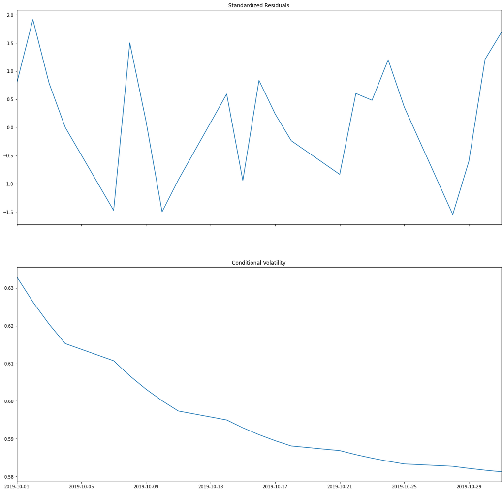

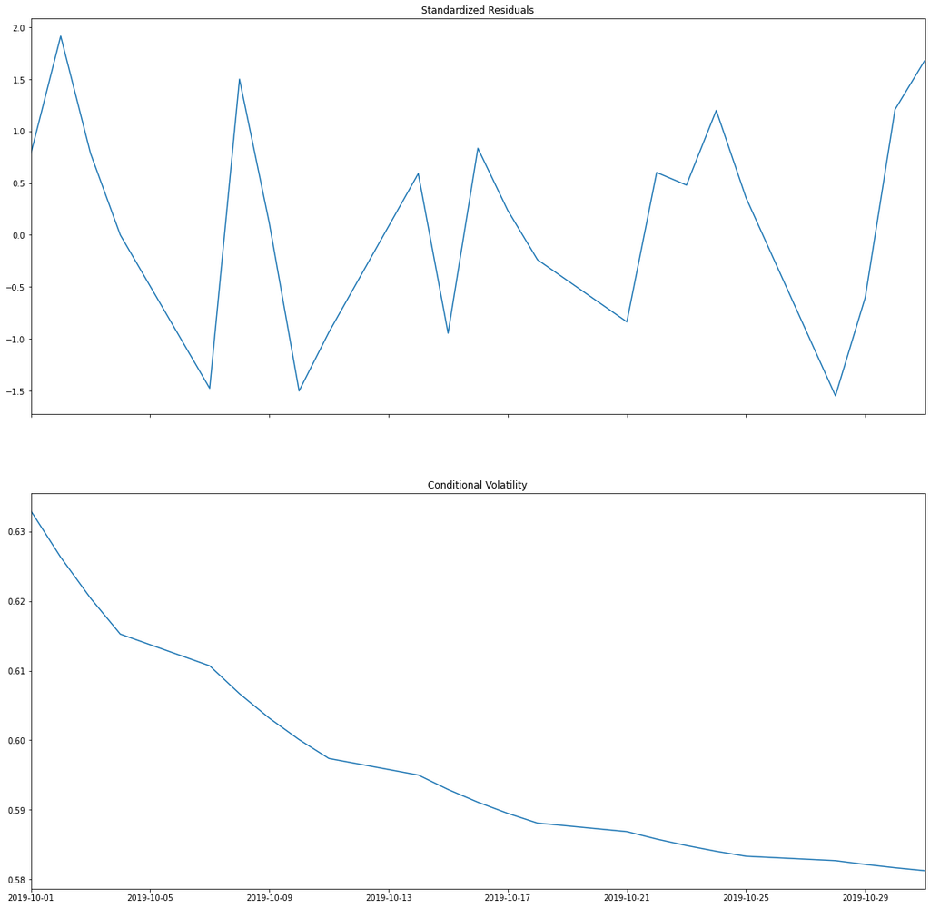

```python
model_fit.plot()
```

```python
#Using the November gold ETF returns, find a GARCH(1,1) model
```

```python
# fiiting GARCH model gold_etf   for  november
model = arch_model(gold_etf_nov.Daily_Returns, mean='Zero', vol='GARCH', p=1, o=0, q=1)
model_fit = model.fit(disp='off')
print(model_fit.summary())
```

```
                       Zero Mean - GARCH Model Results
==============================================================================
Dep. Variable:          Daily_Returns   R-squared:                       0.000
Mean Model:                 Zero Mean   Adj. R-squared:                  0.050
Vol Model:                      GARCH   Log-Likelihood:               -18.0007
Distribution:                  Normal   AIC:                           42.0013
Method:            Maximum Likelihood   BIC:                           44.9885
                                        No. Observations:                   20
Date:                Sun, Jan 10 2021   Df Residuals:                       17
Time:                        16:12:56   Df Model:                            3
                               Volatility Model
=============================================================================
                 coef    std err          t      P>|t|       95.0% Conf. Int.
-----------------------------------------------------------------------------
omega          0.0000  3.048e-02      0.000      1.000 [-5.973e-02,5.973e-02]
alpha[1]       0.0000  6.107e-02      0.000      1.000      [ -0.120,  0.120]
beta[1]        0.9479      0.151      6.289  3.195e-10      [  0.652,  1.243]
=============================================================================

Covariance estimator: robust
```

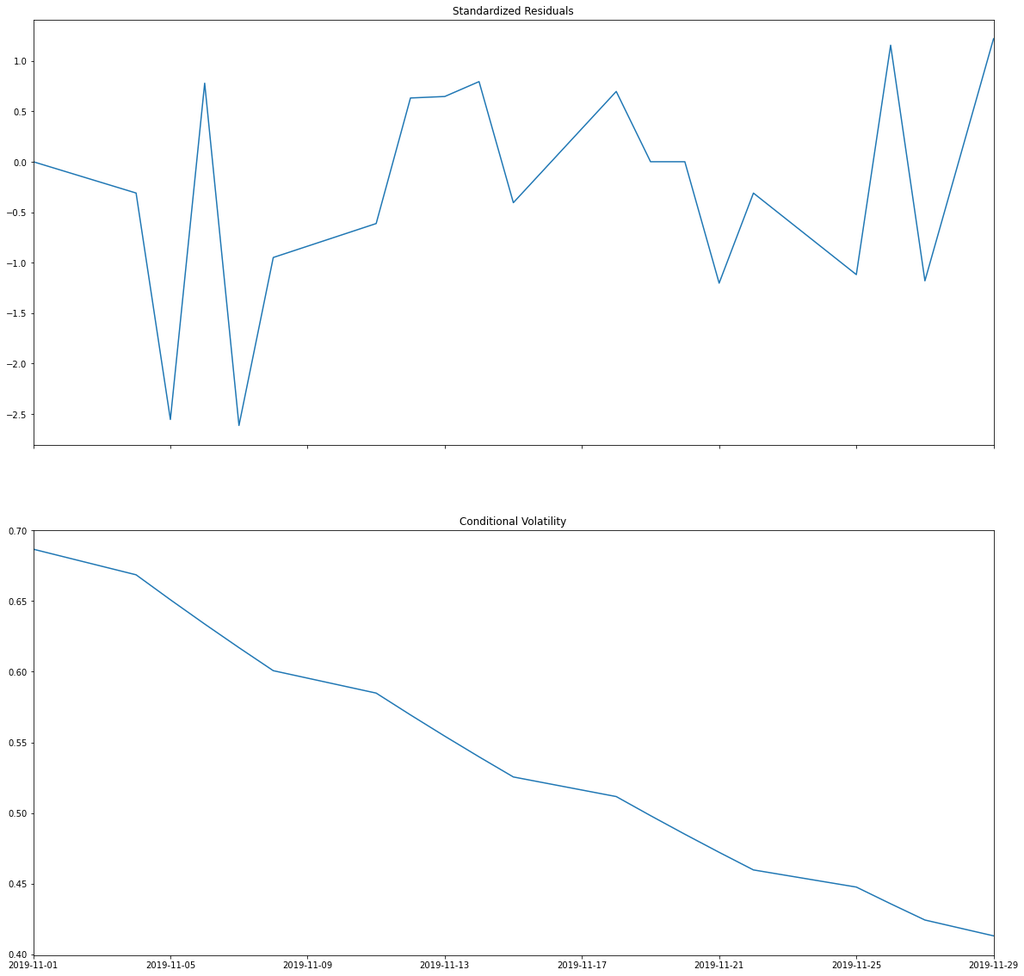

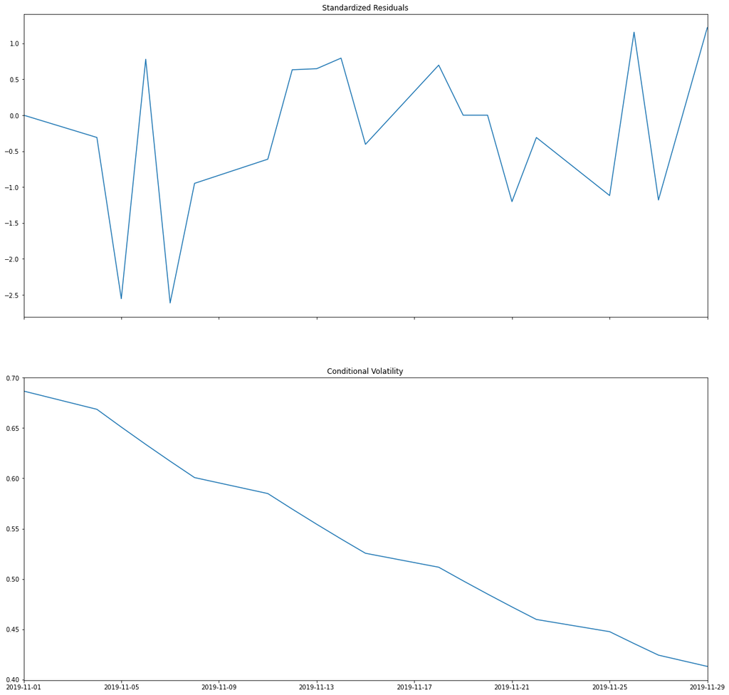

```python
model_fit.plot()
```

```python
#Using equity ETF prices, find the daily high minus low for each month.  Compute the average for October.  Compute the average for November.
# assigning daily volatility column for equity etf data
equity_etf_volat=equity_etf.assign(
daily_volatility=lambda x:x.High-x.Low
)
```

```python
equity_etf_volat
```

| Date | Open | High | Low | Close | Adj Close | Volume | Daily_Returns | daily_volatility |
| --- | --- | --- | --- | --- | --- | --- | --- | --- |
| 2019-10-01 | 119.510002 | 120.000000 | 117.000000 | 117.489998 | 117.489998 | 220359 | -1.649089 | 3.000000 |
| 2019-10-03 | 117.010002 | 117.790001 | 116.500000 | 117.080002 | 117.080002 | 34831 | -0.348962 | 1.290001 |
| 2019-10-04 | 117.400002 | 117.900002 | 115.949997 | 116.029999 | 116.029999 | 96496 | -0.896825 | 1.950005 |
| 2019-10-07 | 116.150002 | 116.699997 | 115.360001 | 115.820000 | 115.820000 | 196701 | -0.180987 | 1.339996 |
| 2019-10-09 | 118.099998 | 128.600006 | 115.250000 | 116.970001 | 116.970001 | 55017 | 0.992921 | 13.350006 |
| 2019-10-10 | 116.820000 | 117.080002 | 116.059998 | 116.449997 | 116.449997 | 18463 | -0.444562 | 1.020004 |
| 2019-10-11 | 116.690002 | 117.470001 | 115.809998 | 116.699997 | 116.699997 | 27325 | 0.214684 | 1.660004 |
| 2019-10-14 | 117.000000 | 117.900002 | 116.800003 | 117.309998 | 117.309998 | 58123 | 0.522708 | 1.099998 |
| 2019-10-15 | 117.599998 | 118.400002 | 117.300003 | 118.000000 | 118.000000 | 65235 | 0.588187 | 1.099998 |
| 2019-10-16 | 115.599998 | 118.699997 | 105.000000 | 118.180000 | 118.180000 | 84462 | 0.152543 | 13.699997 |
| 2019-10-17 | 118.019997 | 119.639999 | 118.019997 | 119.489998 | 119.489998 | 29533 | 1.108477 | 1.620003 |
| 2019-10-18 | 118.949997 | 121.000000 | 118.949997 | 120.360001 | 120.360001 | 102418 | 0.728097 | 2.050003 |
| 2019-10-22 | 120.610001 | 121.000000 | 119.750000 | 119.980003 | 119.980003 | 69537 | -0.315717 | 1.250000 |
| 2019-10-23 | 120.000000 | 120.500000 | 119.500000 | 119.599998 | 119.599998 | 31506 | -0.316724 | 1.000000 |
| 2019-10-24 | 120.059998 | 120.779999 | 119.500000 | 119.910004 | 119.910004 | 49399 | 0.259202 | 1.279999 |
| 2019-10-25 | 119.989998 | 120.599998 | 119.500000 | 120.339996 | 120.339996 | 142949 | 0.358596 | 1.099998 |
| 2019-10-29 | 120.160004 | 122.000000 | 120.120003 | 121.739998 | 121.739998 | 63187 | 1.163372 | 1.879997 |
| 2019-10-30 | 121.699997 | 122.680000 | 121.699997 | 122.120003 | 122.120003 | 56824 | 0.312145 | 0.980003 |
| 2019-10-31 | 122.389999 | 123.199997 | 122.199997 | 122.519997 | 122.519997 | 44133 | 0.327542 | 1.000000 |
| 2019-11-01 | 122.500000 | 123.680000 | 122.260002 | 122.839996 | 122.839996 | 1083750 | 0.261182 | 1.419998 |
| 2019-11-04 | 123.169998 | 123.889999 | 122.489998 | 123.279999 | 123.279999 | 101711 | 0.358192 | 1.400002 |
| 2019-11-05 | 123.099998 | 123.550003 | 122.599998 | 123.220001 | 123.220001 | 25714 | -0.048668 | 0.950005 |
| 2019-11-06 | 123.000000 | 124.000000 | 122.559998 | 123.589996 | 123.589996 | 41912 | 0.300272 | 1.440002 |
| 2019-11-07 | 123.599998 | 124.300003 | 123.500000 | 124.000000 | 124.000000 | 603936 | 0.331745 | 0.800003 |
| 2019-11-08 | 123.800003 | 124.650002 | 123.000000 | 123.269997 | 123.269997 | 125395 | -0.588712 | 1.650002 |
| 2019-11-11 | 123.110001 | 123.720001 | 122.470001 | 123.190002 | 123.190002 | 41667 | -0.064893 | 1.250000 |
| 2019-11-13 | 123.389999 | 123.550003 | 122.169998 | 122.339996 | 122.339996 | 24139 | -0.689996 | 1.380005 |
| 2019-11-14 | 122.680000 | 123.000000 | 121.900002 | 122.480003 | 122.480003 | 1377969 | 0.114441 | 1.099998 |
| 2019-11-15 | 124.900002 | 125.000000 | 122.519997 | 123.089996 | 123.089996 | 896449 | 0.498035 | 2.480003 |
| 2019-11-18 | 123.309998 | 123.320000 | 122.739998 | 122.769997 | 122.769997 | 94057 | -0.259972 | 0.580002 |
| 2019-11-19 | 123.300003 | 123.500000 | 122.550003 | 123.360001 | 123.360001 | 56442 | 0.480577 | 0.949997 |
| 2019-11-20 | 120.900002 | 125.800003 | 109.800003 | 123.779999 | 123.779999 | 90583 | 0.340465 | 16.000000 |
| 2019-11-21 | 124.000000 | 124.400002 | 122.150002 | 123.900002 | 123.900002 | 43621 | 0.096948 | 2.250000 |
| 2019-11-22 | 123.900002 | 123.900002 | 122.900002 | 122.989998 | 122.989998 | 16117 | -0.734466 | 1.000000 |
| 2019-11-25 | 123.230003 | 124.620003 | 122.919998 | 124.570000 | 124.570000 | 170112 | 1.284659 | 1.700005 |
| 2019-11-26 | 124.650002 | 124.949997 | 124.040001 | 124.739998 | 124.739998 | 322450 | 0.136468 | 0.909996 |
| 2019-11-27 | 124.620003 | 124.970001 | 124.599998 | 124.860001 | 124.860001 | 28778 | 0.096202 | 0.370003 |
| 2019-11-28 | 124.739998 | 126.449997 | 124.739998 | 126.300003 | 126.300003 | 948845 | 1.153294 | 1.709999 |
| 2019-11-29 | 126.220001 | 126.220001 | 124.800003 | 125.339996 | 125.339996 | 19046 | -0.760100 | 1.419998 |

```python
#daily volatility avg values  for  oct and nov month
equity_etf_volat[['daily_volatility']].groupby(pd.Grouper(freq="M")).mean()
```

| Date | daily_volatility |
| --- | --- |
| 2019-10-31 | 2.719474 |
| 2019-11-30 | 2.038001 |

```python
#Using equity ETF returns, find the standard deviation for October.  Repeat for November
# equity_etf daily returns standard deviation for oct and nov
equity_etf[['Daily_Returns']].groupby(pd.Grouper(freq='M')).std()
```

| Date | Daily_Returns |
| --- | --- |
| 2019-10-31 | 0.703721 |
| 2019-11-30 | 0.551108 |

```python
#Using October equity ETF returns, find a GARCH(1,1) model.  Repeat for November (3 points)
# equity_ETF GARCH model for oct month
model = arch_model(equity_etf_oct.Daily_Returns, mean='Zero', vol='GARCH', p=1, o=0, q=1)
model_fit = model.fit(disp='off')
print(model_fit.summary())
```

```
                       Zero Mean - GARCH Model Results
==============================================================================
Dep. Variable:          Daily_Returns   R-squared:                       0.000
Mean Model:                 Zero Mean   Adj. R-squared:                  0.053
Vol Model:                      GARCH   Log-Likelihood:               -19.6086
Distribution:                  Normal   AIC:                           45.2172
Method:            Maximum Likelihood   BIC:                           48.0505
                                        No. Observations:                   19
Date:                Sun, Jan 10 2021   Df Residuals:                       16
Time:                        16:28:42   Df Model:                            3
                            Volatility Model
========================================================================
                 coef    std err          t      P>|t|  95.0% Conf. Int.
------------------------------------------------------------------------
omega          0.0213      0.129      0.165      0.869 [ -0.231,  0.274]
alpha[1]       0.0000      0.136      0.000      1.000 [ -0.266,  0.266]
beta[1]        0.9169      0.389      2.359  1.830e-02 [  0.155,  1.679]
========================================================================

Covariance estimator: robust
```

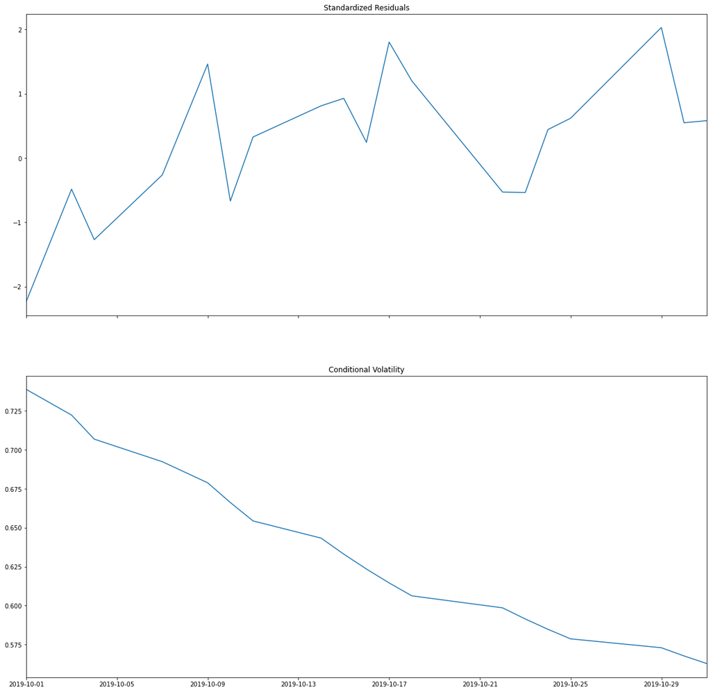

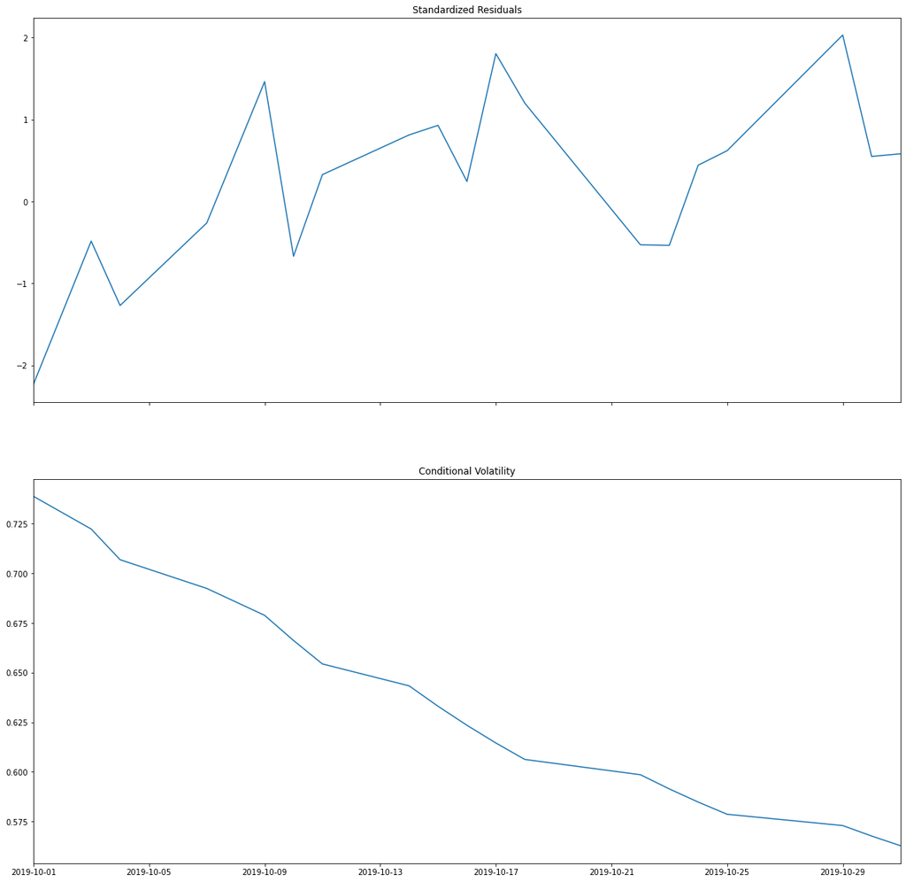

```python
model_fit.plot()
```

```python
# equity_ETF GARCH model for November  month

model = arch_model(equity_etf_nov.Daily_Returns, mean='Zero', vol='GARCH', p=1, o=0, q=1)
model_fit = model.fit(disp='off')
print(model_fit.summary())
```

```
                       Zero Mean - GARCH Model Results
==============================================================================
Dep. Variable:          Daily_Returns   R-squared:                       0.000
Mean Model:                 Zero Mean   Adj. R-squared:                  0.050
Vol Model:                      GARCH   Log-Likelihood:               -15.5855
Distribution:                  Normal   AIC:                           37.1710
Method:            Maximum Likelihood   BIC:                           40.1582
                                        No. Observations:                   20
Date:                Sun, Jan 10 2021   Df Residuals:                       17
Time:                        16:29:08   Df Model:                            3
                            Volatility Model
========================================================================
                 coef    std err          t      P>|t|  95.0% Conf. Int.
------------------------------------------------------------------------
omega      9.7787e-03  8.031e-02      0.122      0.903 [ -0.148,  0.167]
alpha[1]   3.0307e-12      0.142  2.138e-11      1.000 [ -0.278,  0.278]
beta[1]        1.0000      0.297      3.366  7.614e-04 [  0.418,  1.582]
========================================================================

Covariance estimator: robust
```

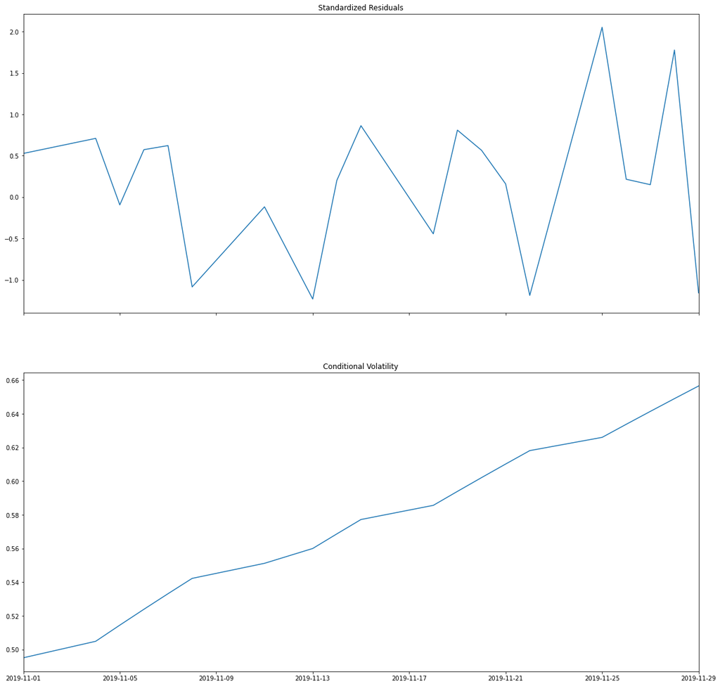

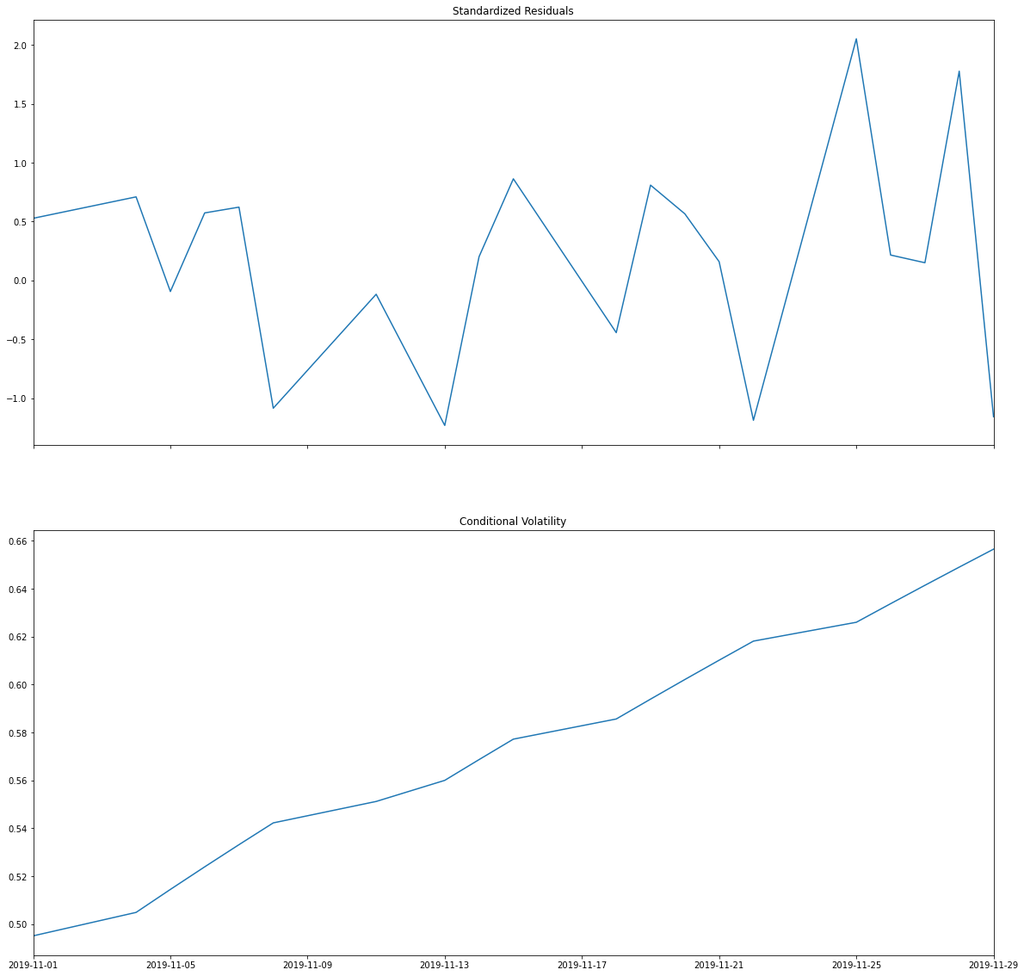

```python
model_fit.plot()
```

# Correlation

```python
#Compute the Pearson correlation between the gold and equity returns in October?  Repeat for November.
import scipy.stats
#scipy.stats.pearsonr(gold_etf_oct.Daily_Returns, equity_etf_oct.Daily_Returns)
print(gold_etf_oct.Daily_Returns.corr(equity_etf_oct.Daily_Returns))
print(gold_etf_nov.Daily_Returns.corr(equity_etf_nov.Daily_Returns))
```

```
-0.08100580314110808
-0.19866821769053386
```